# Wrangling and Analyze Data

## Gathering

```python
# Importing the required modules
import pandas as pd
import numpy as np
import tweepy
import json
import requests
import seaborn as sns
from matplotlib import pyplot as plt
%matplotlib inline
```

```python
# Reading the required files(csv and tsv)
df_twitter = pd.read_csv('twitter-archive-enhanced.csv')
df_img_pred = pd.read_csv('image-predictions.tsv', sep = '\t')
```

```python
import tweepy
from tweepy import OAuthHandler
import json
from timeit import default_timer as timer

consumer_secret = 'HIDDEN'
access_token = 'HIDDEN'
access_secret = 'HIDDEN'

auth = OAuthHandler(consumer_key, consumer_secret)
auth.set_access_token(access_token, access_secret)

api = tweepy.API(auth, wait_on_rate_limit=True)

tweet_ids = df_1.tweet_id.values
len(tweet_ids)

count = 0
fails_dict = {}
start = timer()

with open('tweet_json.txt', 'w') as outfile:
    for tweet_id in tweet_ids:
        count += 1
        print(str(count) + ": " + str(tweet_id))
        try:
            tweet = api.get_status(tweet_id, tweet_mode='extended')
            print("Success")
            json.dump(tweet._json, outfile)
            outfile.write('\n')
        except tweepy.TweepError as e:
            print("Fail")
            fails_dict[tweet_id] = e
            pass
end = timer()
print(end - start)
print(fails_dict)
```

[output not shown]

```python
# Reading json file
df_tweets = pd.read_json("tweet-json.txt", lines = True)
```

## Assess

```python
df_twitter.shape
```

```
(2356, 17)
```

```python
df_twitter
```

|  | tweet_id | in_reply_to_status_id | in_reply_to_user_id | timestamp | source | text | retweeted_status_id | retweeted_status_user_id | retweeted_status_timestamp | expanded_urls | rating_numerator | rating_denominator | name | doggo | floofer | pupper | puppo |
| --- | --- | --- | --- | --- | --- | --- | --- | --- | --- | --- | --- | --- | --- | --- | --- | --- | --- |
| 0 | 892420643555336193 | NaN | NaN | 2017-08-01 16:23:56 +0000 | <a href="http://twitter.com/download/iphone" r... | This is Phineas. He's a mystical boy. Only eve... | NaN | NaN | NaN | https://twitter.com/dog_rates/status/892420643... | 13 | 10 | Phineas | None | None | None | None |
| 1 | 892177421306343426 | NaN | NaN | 2017-08-01 00:17:27 +0000 | <a href="http://twitter.com/download/iphone" r... | This is Tilly. She's just checking pup on you.... | NaN | NaN | NaN | https://twitter.com/dog_rates/status/892177421... | 13 | 10 | Tilly | None | None | None | None |
| 2 | 891815181378084864 | NaN | NaN | 2017-07-31 00:18:03 +0000 | <a href="http://twitter.com/download/iphone" r... | This is Archie. He is a rare Norwegian Pouncin... | NaN | NaN | NaN | https://twitter.com/dog_rates/status/891815181... | 12 | 10 | Archie | None | None | None | None |
| 3 | 891689557279858688 | NaN | NaN | 2017-07-30 15:58:51 +0000 | <a href="http://twitter.com/download/iphone" r... | This is Darla. She commenced a snooze mid meal... | NaN | NaN | NaN | https://twitter.com/dog_rates/status/891689557... | 13 | 10 | Darla | None | None | None | None |
| 4 | 891327558926688256 | NaN | NaN | 2017-07-29 16:00:24 +0000 | <a href="http://twitter.com/download/iphone" r... | This is Franklin. He would like you to stop ca... | NaN | NaN | NaN | https://twitter.com/dog_rates/status/891327558... | 12 | 10 | Franklin | None | None | None | None |
| 5 | 891087950875897856 | NaN | NaN | 2017-07-29 00:08:17 +0000 | <a href="http://twitter.com/download/iphone" r... | Here we have a majestic great white breaching ... | NaN | NaN | NaN | https://twitter.com/dog_rates/status/891087950... | 13 | 10 | None | None | None | None | None |
| 6 | 890971913173991426 | NaN | NaN | 2017-07-28 16:27:12 +0000 | <a href="http://twitter.com/download/iphone" r... | Meet Jax. He enjoys ice cream so much he gets ... | NaN | NaN | NaN | https://gofundme.com/ydvmve-surgery-for-jax,ht... | 13 | 10 | Jax | None | None | None | None |
| 7 | 890729181411237888 | NaN | NaN | 2017-07-28 00:22:40 +0000 | <a href="http://twitter.com/download/iphone" r... | When you watch your owner call another dog a g... | NaN | NaN | NaN | https://twitter.com/dog_rates/status/890729181... | 13 | 10 | None | None | None | None | None |
| 8 | 890609185150312448 | NaN | NaN | 2017-07-27 16:25:51 +0000 | <a href="http://twitter.com/download/iphone" r... | This is Zoey. She doesn't want to be one of th... | NaN | NaN | NaN | https://twitter.com/dog_rates/status/890609185... | 13 | 10 | Zoey | None | None | None | None |
| 9 | 890240255349198849 | NaN | NaN | 2017-07-26 15:59:51 +0000 | <a href="http://twitter.com/download/iphone" r... | This is Cassie. She is a college pup. Studying... | NaN | NaN | NaN | https://twitter.com/dog_rates/status/890240255... | 14 | 10 | Cassie | doggo | None | None | None |
| 10 | 890006608113172480 | NaN | NaN | 2017-07-26 00:31:25 +0000 | <a href="http://twitter.com/download/iphone" r... | This is Koda. He is a South Australian decksha... | NaN | NaN | NaN | https://twitter.com/dog_rates/status/890006608... | 13 | 10 | Koda | None | None | None | None |
| 11 | 889880896479866881 | NaN | NaN | 2017-07-25 16:11:53 +0000 | <a href="http://twitter.com/download/iphone" r... | This is Bruno. He is a service shark. Only get... | NaN | NaN | NaN | https://twitter.com/dog_rates/status/889880896... | 13 | 10 | Bruno | None | None | None | None |
| 12 | 889665388333682689 | NaN | NaN | 2017-07-25 01:55:32 +0000 | <a href="http://twitter.com/download/iphone" r... | Here's a puppo that seems to be on the fence a... | NaN | NaN | NaN | https://twitter.com/dog_rates/status/889665388... | 13 | 10 | None | None | None | None | puppo |
| 13 | 889638837579907072 | NaN | NaN | 2017-07-25 00:10:02 +0000 | <a href="http://twitter.com/download/iphone" r... | This is Ted. He does his best. Sometimes that'... | NaN | NaN | NaN | https://twitter.com/dog_rates/status/889638837... | 12 | 10 | Ted | None | None | None | None |
| 14 | 889531135344209921 | NaN | NaN | 2017-07-24 17:02:04 +0000 | <a href="http://twitter.com/download/iphone" r... | This is Stuart. He's sporting his favorite fan... | NaN | NaN | NaN | https://twitter.com/dog_rates/status/889531135... | 13 | 10 | Stuart | None | None | None | puppo |
| 15 | 889278841981685760 | NaN | NaN | 2017-07-24 00:19:32 +0000 | <a href="http://twitter.com/download/iphone" r... | This is Oliver. You're witnessing one of his m... | NaN | NaN | NaN | https://twitter.com/dog_rates/status/889278841... | 13 | 10 | Oliver | None | None | None | None |
| 16 | 888917238123831296 | NaN | NaN | 2017-07-23 00:22:39 +0000 | <a href="http://twitter.com/download/iphone" r... | This is Jim. He found a fren. Taught him how t... | NaN | NaN | NaN | https://twitter.com/dog_rates/status/888917238... | 12 | 10 | Jim | None | None | None | None |
| 17 | 888804989199671297 | NaN | NaN | 2017-07-22 16:56:37 +0000 | <a href="http://twitter.com/download/iphone" r... | This is Zeke. He has a new stick. Very proud o... | NaN | NaN | NaN | https://twitter.com/dog_rates/status/888804989... | 13 | 10 | Zeke | None | None | None | None |
| 18 | 888554962724278272 | NaN | NaN | 2017-07-22 00:23:06 +0000 | <a href="http://twitter.com/download/iphone" r... | This is Ralphus. He's powering up. Attempting ... | NaN | NaN | NaN | https://twitter.com/dog_rates/status/888554962... | 13 | 10 | Ralphus | None | None | None | None |
| 19 | 888202515573088257 | NaN | NaN | 2017-07-21 01:02:36 +0000 | <a href="http://twitter.com/download/iphone" r... | RT @dog_rates: This is Canela. She attempted s... | 8.874740e+17 | 4.196984e+09 | 2017-07-19 00:47:34 +0000 | https://twitter.com/dog_rates/status/887473957... | 13 | 10 | Canela | None | None | None | None |
| 20 | 888078434458587136 | NaN | NaN | 2017-07-20 16:49:33 +0000 | <a href="http://twitter.com/download/iphone" r... | This is Gerald. He was just told he didn't get... | NaN | NaN | NaN | https://twitter.com/dog_rates/status/888078434... | 12 | 10 | Gerald | None | None | None | None |
| 21 | 887705289381826560 | NaN | NaN | 2017-07-19 16:06:48 +0000 | <a href="http://twitter.com/download/iphone" r... | This is Jeffrey. He has a monopoly on the pool... | NaN | NaN | NaN | https://twitter.com/dog_rates/status/887705289... | 13 | 10 | Jeffrey | None | None | None | None |
| 22 | 887517139158093824 | NaN | NaN | 2017-07-19 03:39:09 +0000 | <a href="http://twitter.com/download/iphone" r... | I've yet to rate a Venezuelan Hover Wiener. Th... | NaN | NaN | NaN | https://twitter.com/dog_rates/status/887517139... | 14 | 10 | such | None | None | None | None |
| 23 | 887473957103951883 | NaN | NaN | 2017-07-19 00:47:34 +0000 | <a href="http://twitter.com/download/iphone" r... | This is Canela. She attempted some fancy porch... | NaN | NaN | NaN | https://twitter.com/dog_rates/status/887473957... | 13 | 10 | Canela | None | None | None | None |
| 24 | 887343217045368832 | NaN | NaN | 2017-07-18 16:08:03 +0000 | <a href="http://twitter.com/download/iphone" r... | You may not have known you needed to see this ... | NaN | NaN | NaN | https://twitter.com/dog_rates/status/887343217... | 13 | 10 | None | None | None | None | None |
| 25 | 887101392804085760 | NaN | NaN | 2017-07-18 00:07:08 +0000 | <a href="http://twitter.com/download/iphone" r... | This... is a Jubilant Antarctic House Bear. We... | NaN | NaN | NaN | https://twitter.com/dog_rates/status/887101392... | 12 | 10 | None | None | None | None | None |
| 26 | 886983233522544640 | NaN | NaN | 2017-07-17 16:17:36 +0000 | <a href="http://twitter.com/download/iphone" r... | This is Maya. She's very shy. Rarely leaves he... | NaN | NaN | NaN | https://twitter.com/dog_rates/status/886983233... | 13 | 10 | Maya | None | None | None | None |
| 27 | 886736880519319552 | NaN | NaN | 2017-07-16 23:58:41 +0000 | <a href="http://twitter.com/download/iphone" r... | This is Mingus. He's a wonderful father to his... | NaN | NaN | NaN | https://www.gofundme.com/mingusneedsus,https:/... | 13 | 10 | Mingus | None | None | None | None |
| 28 | 886680336477933568 | NaN | NaN | 2017-07-16 20:14:00 +0000 | <a href="http://twitter.com/download/iphone" r... | This is Derek. He's late for a dog meeting. 13... | NaN | NaN | NaN | https://twitter.com/dog_rates/status/886680336... | 13 | 10 | Derek | None | None | None | None |
| 29 | 886366144734445568 | NaN | NaN | 2017-07-15 23:25:31 +0000 | <a href="http://twitter.com/download/iphone" r... | This is Roscoe. Another pupper fallen victim t... | NaN | NaN | NaN | https://twitter.com/dog_rates/status/886366144... | 12 | 10 | Roscoe | None | None | pupper | None |
| ... | ... | ... | ... | ... | ... | ... | ... | ... | ... | ... | ... | ... | ... | ... | ... | ... | ... |
| 2326 | 666411507551481857 | NaN | NaN | 2015-11-17 00:24:19 +0000 | <a href="http://twitter.com/download/iphone" r... | This is quite the dog. Gets really excited whe... | NaN | NaN | NaN | https://twitter.com/dog_rates/status/666411507... | 2 | 10 | quite | None | None | None | None |
| 2327 | 666407126856765440 | NaN | NaN | 2015-11-17 00:06:54 +0000 | <a href="http://twitter.com/download/iphone" r... | This is a southern Vesuvius bumblegruff. Can d... | NaN | NaN | NaN | https://twitter.com/dog_rates/status/666407126... | 7 | 10 | a | None | None | None | None |
| 2328 | 666396247373291520 | NaN | NaN | 2015-11-16 23:23:41 +0000 | <a href="http://twitter.com/download/iphone" r... | Oh goodness. A super rare northeast Qdoba kang... | NaN | NaN | NaN | https://twitter.com/dog_rates/status/666396247... | 9 | 10 | None | None | None | None | None |
| 2329 | 666373753744588802 | NaN | NaN | 2015-11-16 21:54:18 +0000 | <a href="http://twitter.com/download/iphone" r... | Those are sunglasses and a jean jacket. 11/10 ... | NaN | NaN | NaN | https://twitter.com/dog_rates/status/666373753... | 11 | 10 | None | None | None | None | None |
| 2330 | 666362758909284353 | NaN | NaN | 2015-11-16 21:10:36 +0000 | <a href="http://twitter.com/download/iphone" r... | Unique dog here. Very small. Lives in containe... | NaN | NaN | NaN | https://twitter.com/dog_rates/status/666362758... | 6 | 10 | None | None | None | None | None |
| 2331 | 666353288456101888 | NaN | NaN | 2015-11-16 20:32:58 +0000 | <a href="http://twitter.com/download/iphone" r... | Here we have a mixed Asiago from the Galápagos... | NaN | NaN | NaN | https://twitter.com/dog_rates/status/666353288... | 8 | 10 | None | None | None | None | None |
| 2332 | 666345417576210432 | NaN | NaN | 2015-11-16 20:01:42 +0000 | <a href="http://twitter.com/download/iphone" r... | Look at this jokester thinking seat belt laws ... | NaN | NaN | NaN | https://twitter.com/dog_rates/status/666345417... | 10 | 10 | None | None | None | None | None |
| 2333 | 666337882303524864 | NaN | NaN | 2015-11-16 19:31:45 +0000 | <a href="http://twitter.com/download/iphone" r... | This is an extremely rare horned Parthenon. No... | NaN | NaN | NaN | https://twitter.com/dog_rates/status/666337882... | 9 | 10 | an | None | None | None | None |
| 2334 | 666293911632134144 | NaN | NaN | 2015-11-16 16:37:02 +0000 | <a href="http://twitter.com/download/iphone" r... | This is a funny dog. Weird toes. Won't come do... | NaN | NaN | NaN | https://twitter.com/dog_rates/status/666293911... | 3 | 10 | a | None | None | None | None |
| 2335 | 666287406224695296 | NaN | NaN | 2015-11-16 16:11:11 +0000 | <a href="http://twitter.com/download/iphone" r... | This is an Albanian 3 1/2 legged Episcopalian... | NaN | NaN | NaN | https://twitter.com/dog_rates/status/666287406... | 1 | 2 | an | None | None | None | None |
| 2336 | 666273097616637952 | NaN | NaN | 2015-11-16 15:14:19 +0000 | <a href="http://twitter.com/download/iphone" r... | Can take selfies 11/10 https://t.co/ws2AMaNwPW | NaN | NaN | NaN | https://twitter.com/dog_rates/status/666273097... | 11 | 10 | None | None | None | None | None |
| 2337 | 666268910803644416 | NaN | NaN | 2015-11-16 14:57:41 +0000 | <a href="http://twitter.com/download/iphone" r... | Very concerned about fellow dog trapped in com... | NaN | NaN | NaN | https://twitter.com/dog_rates/status/666268910... | 10 | 10 | None | None | None | None | None |
| 2338 | 666104133288665088 | NaN | NaN | 2015-11-16 04:02:55 +0000 | <a href="http://twitter.com/download/iphone" r... | Not familiar with this breed. No tail (weird).... | NaN | NaN | NaN | https://twitter.com/dog_rates/status/666104133... | 1 | 10 | None | None | None | None | None |
| 2339 | 666102155909144576 | NaN | NaN | 2015-11-16 03:55:04 +0000 | <a href="http://twitter.com/download/iphone" r... | Oh my. Here you are seeing an Adobe Setter giv... | NaN | NaN | NaN | https://twitter.com/dog_rates/status/666102155... | 11 | 10 | None | None | None | None | None |
| 2340 | 666099513787052032 | NaN | NaN | 2015-11-16 03:44:34 +0000 | <a href="http://twitter.com/download/iphone" r... | Can stand on stump for what seems like a while... | NaN | NaN | NaN | https://twitter.com/dog_rates/status/666099513... | 8 | 10 | None | None | None | None | None |
| 2341 | 666094000022159362 | NaN | NaN | 2015-11-16 03:22:39 +0000 | <a href="http://twitter.com/download/iphone" r... | This appears to be a Mongolian Presbyterian mi... | NaN | NaN | NaN | https://twitter.com/dog_rates/status/666094000... | 9 | 10 | None | None | None | None | None |
| 2342 | 666082916733198337 | NaN | NaN | 2015-11-16 02:38:37 +0000 | <a href="http://twitter.com/download/iphone" r... | Here we have a well-established sunblockerspan... | NaN | NaN | NaN | https://twitter.com/dog_rates/status/666082916... | 6 | 10 | None | None | None | None | None |
| 2343 | 666073100786774016 | NaN | NaN | 2015-11-16 01:59:36 +0000 | <a href="http://twitter.com/download/iphone" r... | Let's hope this flight isn't Malaysian (lol). ... | NaN | NaN | NaN | https://twitter.com/dog_rates/status/666073100... | 10 | 10 | None | None | None | None | None |
| 2344 | 666071193221509120 | NaN | NaN | 2015-11-16 01:52:02 +0000 | <a href="http://twitter.com/download/iphone" r... | Here we have a northern speckled Rhododendron.... | NaN | NaN | NaN | https://twitter.com/dog_rates/status/666071193... | 9 | 10 | None | None | None | None | None |
| 2345 | 666063827256086533 | NaN | NaN | 2015-11-16 01:22:45 +0000 | <a href="http://twitter.com/download/iphone" r... | This is the happiest dog you will ever see. Ve... | NaN | NaN | NaN | https://twitter.com/dog_rates/status/666063827... | 10 | 10 | the | None | None | None | None |
| 2346 | 666058600524156928 | NaN | NaN | 2015-11-16 01:01:59 +0000 | <a href="http://twitter.com/download/iphone" r... | Here is the Rand Paul of retrievers folks! He'... | NaN | NaN | NaN | https://twitter.com/dog_rates/status/666058600... | 8 | 10 | the | None | None | None | None |
| 2347 | 666057090499244032 | NaN | NaN | 2015-11-16 00:55:59 +0000 | <a href="http://twitter.com/download/iphone" r... | My oh my. This is a rare blond Canadian terrie... | NaN | NaN | NaN | https://twitter.com/dog_rates/status/666057090... | 9 | 10 | a | None | None | None | None |
| 2348 | 666055525042405380 | NaN | NaN | 2015-11-16 00:49:46 +0000 | <a href="http://twitter.com/download/iphone" r... | Here is a Siberian heavily armored polar bear ... | NaN | NaN | NaN | https://twitter.com/dog_rates/status/666055525... | 10 | 10 | a | None | None | None | None |
| 2349 | 666051853826850816 | NaN | NaN | 2015-11-16 00:35:11 +0000 | <a href="http://twitter.com/download/iphone" r... | This is an odd dog. Hard on the outside but lo... | NaN | NaN | NaN | https://twitter.com/dog_rates/status/666051853... | 2 | 10 | an | None | None | None | None |
| 2350 | 666050758794694657 | NaN | NaN | 2015-11-16 00:30:50 +0000 | <a href="http://twitter.com/download/iphone" r... | This is a truly beautiful English Wilson Staff... | NaN | NaN | NaN | https://twitter.com/dog_rates/status/666050758... | 10 | 10 | a | None | None | None | None |
| 2351 | 666049248165822465 | NaN | NaN | 2015-11-16 00:24:50 +0000 | <a href="http://twitter.com/download/iphone" r... | Here we have a 1949 1st generation vulpix. Enj... | NaN | NaN | NaN | https://twitter.com/dog_rates/status/666049248... | 5 | 10 | None | None | None | None | None |
| 2352 | 666044226329800704 | NaN | NaN | 2015-11-16 00:04:52 +0000 | <a href="http://twitter.com/download/iphone" r... | This is a purebred Piers Morgan. Loves to Netf... | NaN | NaN | NaN | https://twitter.com/dog_rates/status/666044226... | 6 | 10 | a | None | None | None | None |
| 2353 | 666033412701032449 | NaN | NaN | 2015-11-15 23:21:54 +0000 | <a href="http://twitter.com/download/iphone" r... | Here is a very happy pup. Big fan of well-main... | NaN | NaN | NaN | https://twitter.com/dog_rates/status/666033412... | 9 | 10 | a | None | None | None | None |
| 2354 | 666029285002620928 | NaN | NaN | 2015-11-15 23:05:30 +0000 | <a href="http://twitter.com/download/iphone" r... | This is a western brown Mitsubishi terrier. Up... | NaN | NaN | NaN | https://twitter.com/dog_rates/status/666029285... | 7 | 10 | a | None | None | None | None |
| 2355 | 666020888022790149 | NaN | NaN | 2015-11-15 22:32:08 +0000 | <a href="http://twitter.com/download/iphone" r... | Here we have a Japanese Irish Setter. Lost eye... | NaN | NaN | NaN | https://twitter.com/dog_rates/status/666020888... | 8 | 10 | None | None | None | None | None |

2356 rows × 17 columns

```python
# A concise summary of a DataFrame
df_twitter.info()
```

```
<class 'pandas.core.frame.DataFrame'>
RangeIndex: 2356 entries, 0 to 2355
Data columns (total 17 columns):
tweet_id                      2356 non-null int64
in_reply_to_status_id         78 non-null float64
in_reply_to_user_id           78 non-null float64
timestamp                     2356 non-null object
source                        2356 non-null object
text                          2356 non-null object
retweeted_status_id           181 non-null float64
retweeted_status_user_id      181 non-null float64
retweeted_status_timestamp    181 non-null object
expanded_urls                 2297 non-null object
rating_numerator              2356 non-null int64
rating_denominator            2356 non-null int64
name                          2356 non-null object
doggo                         2356 non-null object
floofer                       2356 non-null object
pupper                        2356 non-null object
puppo                         2356 non-null object
dtypes: float64(4), int64(3), object(10)
memory usage: 313.0+ KB
```

```python
# Viewing data to determine appearance
df_twitter.retweeted_status_timestamp.value_counts().head(3)
```

```
2016-01-25 00:26:41 +0000    1
2016-06-08 02:41:38 +0000    1
2016-07-27 00:40:12 +0000    1
Name: retweeted_status_timestamp, dtype: int64
```

```python
# Viewing data to determine appearance
df_twitter.retweeted_status_id.value_counts().head(3)
```

```
7.757333e+17    1
7.507196e+17    1
6.742918e+17    1
Name: retweeted_status_id, dtype: int64
```

```python
# Descriptive statistics of a DataFrame
df_twitter.describe()
```

|  | tweet_id | in_reply_to_status_id | in_reply_to_user_id | retweeted_status_id | retweeted_status_user_id | rating_numerator | rating_denominator |
| --- | --- | --- | --- | --- | --- | --- | --- |
| count | 2.356000e+03 | 7.800000e+01 | 7.800000e+01 | 1.810000e+02 | 1.810000e+02 | 2356.000000 | 2356.000000 |
| mean | 7.427716e+17 | 7.455079e+17 | 2.014171e+16 | 7.720400e+17 | 1.241698e+16 | 13.126486 | 10.455433 |
| std | 6.856705e+16 | 7.582492e+16 | 1.252797e+17 | 6.236928e+16 | 9.599254e+16 | 45.876648 | 6.745237 |
| min | 6.660209e+17 | 6.658147e+17 | 1.185634e+07 | 6.661041e+17 | 7.832140e+05 | 0.000000 | 0.000000 |
| 25% | 6.783989e+17 | 6.757419e+17 | 3.086374e+08 | 7.186315e+17 | 4.196984e+09 | 10.000000 | 10.000000 |
| 50% | 7.196279e+17 | 7.038708e+17 | 4.196984e+09 | 7.804657e+17 | 4.196984e+09 | 11.000000 | 10.000000 |
| 75% | 7.993373e+17 | 8.257804e+17 | 4.196984e+09 | 8.203146e+17 | 4.196984e+09 | 12.000000 | 10.000000 |
| max | 8.924206e+17 | 8.862664e+17 | 8.405479e+17 | 8.874740e+17 | 7.874618e+17 | 1776.000000 | 170.000000 |

```python
df_twitter.source.value_counts()
```

```
<a href="http://twitter.com/download/iphone" rel="nofollow">Twitter for iPhone</a>     2221
<a href="http://vine.co" rel="nofollow">Vine - Make a Scene</a>                          91
<a href="http://twitter.com" rel="nofollow">Twitter Web Client</a>                       33
<a href="https://about.twitter.com/products/tweetdeck" rel="nofollow">TweetDeck</a>      11
Name: source, dtype: int64
```

```python
df_twitter.rating_denominator.value_counts()
```

```
10     2333
11        3
50        3
80        2
20        2
2         1
16        1
40        1
70        1
15        1
90        1
110       1
120       1
130       1
150       1
170       1
7         1
0         1
Name: rating_denominator, dtype: int64
```

```python
df_twitter.rating_numerator.value_counts()
```

```
12      558
11      464
10      461
13      351
9       158
8       102
7        55
14       54
5        37
6        32
3        19
4        17
1         9
2         9
420       2
```

[output cut: 26 more lines]

```python
df_img_pred.shape
```

```
(2075, 12)
```

```python
df_img_pred
```

|  | tweet_id | jpg_url | img_num | p1 | p1_conf | p1_dog | p2 | p2_conf | p2_dog | p3 | p3_conf | p3_dog |
| --- | --- | --- | --- | --- | --- | --- | --- | --- | --- | --- | --- | --- |
| 0 | 666020888022790149 | https://pbs.twimg.com/media/CT4udn0WwAA0aMy.jpg | 1 | Welsh_springer_spaniel | 0.465074 | True | collie | 0.156665 | True | Shetland_sheepdog | 0.061428 | True |
| 1 | 666029285002620928 | https://pbs.twimg.com/media/CT42GRgUYAA5iDo.jpg | 1 | redbone | 0.506826 | True | miniature_pinscher | 0.074192 | True | Rhodesian_ridgeback | 0.072010 | True |
| 2 | 666033412701032449 | https://pbs.twimg.com/media/CT4521TWwAEvMyu.jpg | 1 | German_shepherd | 0.596461 | True | malinois | 0.138584 | True | bloodhound | 0.116197 | True |
| 3 | 666044226329800704 | https://pbs.twimg.com/media/CT5Dr8HUEAA-lEu.jpg | 1 | Rhodesian_ridgeback | 0.408143 | True | redbone | 0.360687 | True | miniature_pinscher | 0.222752 | True |
| 4 | 666049248165822465 | https://pbs.twimg.com/media/CT5IQmsXIAAKY4A.jpg | 1 | miniature_pinscher | 0.560311 | True | Rottweiler | 0.243682 | True | Doberman | 0.154629 | True |
| 5 | 666050758794694657 | https://pbs.twimg.com/media/CT5Jof1WUAEuVxN.jpg | 1 | Bernese_mountain_dog | 0.651137 | True | English_springer | 0.263788 | True | Greater_Swiss_Mountain_dog | 0.016199 | True |
| 6 | 666051853826850816 | https://pbs.twimg.com/media/CT5KoJ1WoAAJash.jpg | 1 | box_turtle | 0.933012 | False | mud_turtle | 0.045885 | False | terrapin | 0.017885 | False |
| 7 | 666055525042405380 | https://pbs.twimg.com/media/CT5N9tpXIAAifs1.jpg | 1 | chow | 0.692517 | True | Tibetan_mastiff | 0.058279 | True | fur_coat | 0.054449 | False |
| 8 | 666057090499244032 | https://pbs.twimg.com/media/CT5PY90WoAAQGLo.jpg | 1 | shopping_cart | 0.962465 | False | shopping_basket | 0.014594 | False | golden_retriever | 0.007959 | True |
| 9 | 666058600524156928 | https://pbs.twimg.com/media/CT5Qw94XAAA_2dP.jpg | 1 | miniature_poodle | 0.201493 | True | komondor | 0.192305 | True | soft-coated_wheaten_terrier | 0.082086 | True |
| 10 | 666063827256086533 | https://pbs.twimg.com/media/CT5Vg_wXIAAXfnj.jpg | 1 | golden_retriever | 0.775930 | True | Tibetan_mastiff | 0.093718 | True | Labrador_retriever | 0.072427 | True |
| 11 | 666071193221509120 | https://pbs.twimg.com/media/CT5cN_3WEAAlOoZ.jpg | 1 | Gordon_setter | 0.503672 | True | Yorkshire_terrier | 0.174201 | True | Pekinese | 0.109454 | True |
| 12 | 666073100786774016 | https://pbs.twimg.com/media/CT5d9DZXAAALcwe.jpg | 1 | Walker_hound | 0.260857 | True | English_foxhound | 0.175382 | True | Ibizan_hound | 0.097471 | True |
| 13 | 666082916733198337 | https://pbs.twimg.com/media/CT5m4VGWEAAtKc8.jpg | 1 | pug | 0.489814 | True | bull_mastiff | 0.404722 | True | French_bulldog | 0.048960 | True |
| 14 | 666094000022159362 | https://pbs.twimg.com/media/CT5w9gUW4AAsBNN.jpg | 1 | bloodhound | 0.195217 | True | German_shepherd | 0.078260 | True | malinois | 0.075628 | True |
| 15 | 666099513787052032 | https://pbs.twimg.com/media/CT51-JJUEAA6hV8.jpg | 1 | Lhasa | 0.582330 | True | Shih-Tzu | 0.166192 | True | Dandie_Dinmont | 0.089688 | True |
| 16 | 666102155909144576 | https://pbs.twimg.com/media/CT54YGiWUAEZnoK.jpg | 1 | English_setter | 0.298617 | True | Newfoundland | 0.149842 | True | borzoi | 0.133649 | True |
| 17 | 666104133288665088 | https://pbs.twimg.com/media/CT56LSZWoAAlJj2.jpg | 1 | hen | 0.965932 | False | cock | 0.033919 | False | partridge | 0.000052 | False |
| 18 | 666268910803644416 | https://pbs.twimg.com/media/CT8QCd1WEAADXws.jpg | 1 | desktop_computer | 0.086502 | False | desk | 0.085547 | False | bookcase | 0.079480 | False |
| 19 | 666273097616637952 | https://pbs.twimg.com/media/CT8T1mtUwAA3aqm.jpg | 1 | Italian_greyhound | 0.176053 | True | toy_terrier | 0.111884 | True | basenji | 0.111152 | True |
| 20 | 666287406224695296 | https://pbs.twimg.com/media/CT8g3BpUEAAuFjg.jpg | 1 | Maltese_dog | 0.857531 | True | toy_poodle | 0.063064 | True | miniature_poodle | 0.025581 | True |
| 21 | 666293911632134144 | https://pbs.twimg.com/media/CT8mx7KW4AEQu8N.jpg | 1 | three-toed_sloth | 0.914671 | False | otter | 0.015250 | False | great_grey_owl | 0.013207 | False |
| 22 | 666337882303524864 | https://pbs.twimg.com/media/CT9OwFIWEAMuRje.jpg | 1 | ox | 0.416669 | False | Newfoundland | 0.278407 | True | groenendael | 0.102643 | True |
| 23 | 666345417576210432 | https://pbs.twimg.com/media/CT9Vn7PWoAA_ZCM.jpg | 1 | golden_retriever | 0.858744 | True | Chesapeake_Bay_retriever | 0.054787 | True | Labrador_retriever | 0.014241 | True |
| 24 | 666353288456101888 | https://pbs.twimg.com/media/CT9cx0tUEAAhNN_.jpg | 1 | malamute | 0.336874 | True | Siberian_husky | 0.147655 | True | Eskimo_dog | 0.093412 | True |
| 25 | 666362758909284353 | https://pbs.twimg.com/media/CT9lXGsUcAAyUFt.jpg | 1 | guinea_pig | 0.996496 | False | skunk | 0.002402 | False | hamster | 0.000461 | False |
| 26 | 666373753744588802 | https://pbs.twimg.com/media/CT9vZEYWUAAlZ05.jpg | 1 | soft-coated_wheaten_terrier | 0.326467 | True | Afghan_hound | 0.259551 | True | briard | 0.206803 | True |
| 27 | 666396247373291520 | https://pbs.twimg.com/media/CT-D2ZHWIAA3gK1.jpg | 1 | Chihuahua | 0.978108 | True | toy_terrier | 0.009397 | True | papillon | 0.004577 | True |
| 28 | 666407126856765440 | https://pbs.twimg.com/media/CT-NvwmW4AAugGZ.jpg | 1 | black-and-tan_coonhound | 0.529139 | True | bloodhound | 0.244220 | True | flat-coated_retriever | 0.173810 | True |
| 29 | 666411507551481857 | https://pbs.twimg.com/media/CT-RugiWIAELEaq.jpg | 1 | coho | 0.404640 | False | barracouta | 0.271485 | False | gar | 0.189945 | False |
| ... | ... | ... | ... | ... | ... | ... | ... | ... | ... | ... | ... | ... |
| 2045 | 886366144734445568 | https://pbs.twimg.com/media/DE0BTnQUwAApKEH.jpg | 1 | French_bulldog | 0.999201 | True | Chihuahua | 0.000361 | True | Boston_bull | 0.000076 | True |
| 2046 | 886680336477933568 | https://pbs.twimg.com/media/DE4fEDzWAAAyHMM.jpg | 1 | convertible | 0.738995 | False | sports_car | 0.139952 | False | car_wheel | 0.044173 | False |
| 2047 | 886736880519319552 | https://pbs.twimg.com/media/DE5Se8FXcAAJFx4.jpg | 1 | kuvasz | 0.309706 | True | Great_Pyrenees | 0.186136 | True | Dandie_Dinmont | 0.086346 | True |
| 2048 | 886983233522544640 | https://pbs.twimg.com/media/DE8yicJW0AAAvBJ.jpg | 2 | Chihuahua | 0.793469 | True | toy_terrier | 0.143528 | True | can_opener | 0.032253 | False |
| 2049 | 887101392804085760 | https://pbs.twimg.com/media/DE-eAq6UwAA-jaE.jpg | 1 | Samoyed | 0.733942 | True | Eskimo_dog | 0.035029 | True | Staffordshire_bullterrier | 0.029705 | True |
| 2050 | 887343217045368832 | https://pbs.twimg.com/ext_tw_video_thumb/88734... | 1 | Mexican_hairless | 0.330741 | True | sea_lion | 0.275645 | False | Weimaraner | 0.134203 | True |
| 2051 | 887473957103951883 | https://pbs.twimg.com/media/DFDw2tyUQAAAFke.jpg | 2 | Pembroke | 0.809197 | True | Rhodesian_ridgeback | 0.054950 | True | beagle | 0.038915 | True |
| 2052 | 887517139158093824 | https://pbs.twimg.com/ext_tw_video_thumb/88751... | 1 | limousine | 0.130432 | False | tow_truck | 0.029175 | False | shopping_cart | 0.026321 | False |
| 2053 | 887705289381826560 | https://pbs.twimg.com/media/DFHDQBbXgAEqY7t.jpg | 1 | basset | 0.821664 | True | redbone | 0.087582 | True | Weimaraner | 0.026236 | True |
| 2054 | 888078434458587136 | https://pbs.twimg.com/media/DFMWn56WsAAkA7B.jpg | 1 | French_bulldog | 0.995026 | True | pug | 0.000932 | True | bull_mastiff | 0.000903 | True |
| 2055 | 888202515573088257 | https://pbs.twimg.com/media/DFDw2tyUQAAAFke.jpg | 2 | Pembroke | 0.809197 | True | Rhodesian_ridgeback | 0.054950 | True | beagle | 0.038915 | True |
| 2056 | 888554962724278272 | https://pbs.twimg.com/media/DFTH_O-UQAACu20.jpg | 3 | Siberian_husky | 0.700377 | True | Eskimo_dog | 0.166511 | True | malamute | 0.111411 | True |
| 2057 | 888804989199671297 | https://pbs.twimg.com/media/DFWra-3VYAA2piG.jpg | 1 | golden_retriever | 0.469760 | True | Labrador_retriever | 0.184172 | True | English_setter | 0.073482 | True |
| 2058 | 888917238123831296 | https://pbs.twimg.com/media/DFYRgsOUQAARGhO.jpg | 1 | golden_retriever | 0.714719 | True | Tibetan_mastiff | 0.120184 | True | Labrador_retriever | 0.105506 | True |
| 2059 | 889278841981685760 | https://pbs.twimg.com/ext_tw_video_thumb/88927... | 1 | whippet | 0.626152 | True | borzoi | 0.194742 | True | Saluki | 0.027351 | True |
| 2060 | 889531135344209921 | https://pbs.twimg.com/media/DFg_2PVW0AEHN3p.jpg | 1 | golden_retriever | 0.953442 | True | Labrador_retriever | 0.013834 | True | redbone | 0.007958 | True |
| 2061 | 889638837579907072 | https://pbs.twimg.com/media/DFihzFfXsAYGDPR.jpg | 1 | French_bulldog | 0.991650 | True | boxer | 0.002129 | True | Staffordshire_bullterrier | 0.001498 | True |
| 2062 | 889665388333682689 | https://pbs.twimg.com/media/DFi579UWsAAatzw.jpg | 1 | Pembroke | 0.966327 | True | Cardigan | 0.027356 | True | basenji | 0.004633 | True |
| 2063 | 889880896479866881 | https://pbs.twimg.com/media/DFl99B1WsAITKsg.jpg | 1 | French_bulldog | 0.377417 | True | Labrador_retriever | 0.151317 | True | muzzle | 0.082981 | False |
| 2064 | 890006608113172480 | https://pbs.twimg.com/media/DFnwSY4WAAAMliS.jpg | 1 | Samoyed | 0.957979 | True | Pomeranian | 0.013884 | True | chow | 0.008167 | True |
| 2065 | 890240255349198849 | https://pbs.twimg.com/media/DFrEyVuW0AAO3t9.jpg | 1 | Pembroke | 0.511319 | True | Cardigan | 0.451038 | True | Chihuahua | 0.029248 | True |
| 2066 | 890609185150312448 | https://pbs.twimg.com/media/DFwUU__XcAEpyXI.jpg | 1 | Irish_terrier | 0.487574 | True | Irish_setter | 0.193054 | True | Chesapeake_Bay_retriever | 0.118184 | True |
| 2067 | 890729181411237888 | https://pbs.twimg.com/media/DFyBahAVwAAhUTd.jpg | 2 | Pomeranian | 0.566142 | True | Eskimo_dog | 0.178406 | True | Pembroke | 0.076507 | True |
| 2068 | 890971913173991426 | https://pbs.twimg.com/media/DF1eOmZXUAALUcq.jpg | 1 | Appenzeller | 0.341703 | True | Border_collie | 0.199287 | True | ice_lolly | 0.193548 | False |
| 2069 | 891087950875897856 | https://pbs.twimg.com/media/DF3HwyEWsAABqE6.jpg | 1 | Chesapeake_Bay_retriever | 0.425595 | True | Irish_terrier | 0.116317 | True | Indian_elephant | 0.076902 | False |
| 2070 | 891327558926688256 | https://pbs.twimg.com/media/DF6hr6BUMAAzZgT.jpg | 2 | basset | 0.555712 | True | English_springer | 0.225770 | True | German_short-haired_pointer | 0.175219 | True |
| 2071 | 891689557279858688 | https://pbs.twimg.com/media/DF_q7IAWsAEuuN8.jpg | 1 | paper_towel | 0.170278 | False | Labrador_retriever | 0.168086 | True | spatula | 0.040836 | False |
| 2072 | 891815181378084864 | https://pbs.twimg.com/media/DGBdLU1WsAANxJ9.jpg | 1 | Chihuahua | 0.716012 | True | malamute | 0.078253 | True | kelpie | 0.031379 | True |
| 2073 | 892177421306343426 | https://pbs.twimg.com/media/DGGmoV4XsAAUL6n.jpg | 1 | Chihuahua | 0.323581 | True | Pekinese | 0.090647 | True | papillon | 0.068957 | True |
| 2074 | 892420643555336193 | https://pbs.twimg.com/media/DGKD1-bXoAAIAUK.jpg | 1 | orange | 0.097049 | False | bagel | 0.085851 | False | banana | 0.076110 | False |

2075 rows × 12 columns

```python
# A concise summary of a DataFrame
df_img_pred.info()
```

```
<class 'pandas.core.frame.DataFrame'>
RangeIndex: 2075 entries, 0 to 2074
Data columns (total 12 columns):
tweet_id    2075 non-null int64
jpg_url     2075 non-null object
img_num     2075 non-null int64
p1          2075 non-null object
p1_conf     2075 non-null float64
p1_dog      2075 non-null bool
p2          2075 non-null object
p2_conf     2075 non-null float64
p2_dog      2075 non-null bool
p3          2075 non-null object
p3_conf     2075 non-null float64
p3_dog      2075 non-null bool
dtypes: bool(3), float64(3), int64(2), object(4)
memory usage: 152.1+ KB
```

```python
# Descriptive statistics of a DataFrame
df_img_pred.describe()
```

|  | tweet_id | img_num | p1_conf | p2_conf | p3_conf |
| --- | --- | --- | --- | --- | --- |
| count | 2.075000e+03 | 2075.000000 | 2075.000000 | 2.075000e+03 | 2.075000e+03 |
| mean | 7.384514e+17 | 1.203855 | 0.594548 | 1.345886e-01 | 6.032417e-02 |
| std | 6.785203e+16 | 0.561875 | 0.271174 | 1.006657e-01 | 5.090593e-02 |
| min | 6.660209e+17 | 1.000000 | 0.044333 | 1.011300e-08 | 1.740170e-10 |
| 25% | 6.764835e+17 | 1.000000 | 0.364412 | 5.388625e-02 | 1.622240e-02 |
| 50% | 7.119988e+17 | 1.000000 | 0.588230 | 1.181810e-01 | 4.944380e-02 |
| 75% | 7.932034e+17 | 1.000000 | 0.843855 | 1.955655e-01 | 9.180755e-02 |
| max | 8.924206e+17 | 4.000000 | 1.000000 | 4.880140e-01 | 2.734190e-01 |

```python
df_tweets.shape
```

```
(2354, 31)
```

```python
df_tweets
```

|  | contributors | coordinates | created_at | display_text_range | entities | extended_entities | favorite_count | favorited | full_text | geo | ... | possibly_sensitive_appealable | quoted_status | quoted_status_id | quoted_status_id_str | retweet_count | retweeted | retweeted_status | source | truncated | user |
| --- | --- | --- | --- | --- | --- | --- | --- | --- | --- | --- | --- | --- | --- | --- | --- | --- | --- | --- | --- | --- | --- |
| 0 | NaN | NaN | 2017-08-01 16:23:56 | [0, 85] | {'hashtags': [], 'symbols': [], 'user_mentions... | {'media': [{'id': 892420639486877696, 'id_str'... | 39467 | False | This is Phineas. He's a mystical boy. Only eve... | NaN | ... | 0.0 | NaN | NaN | NaN | 8853 | False | NaN | <a href="http://twitter.com/download/iphone" r... | False | {'id': 4196983835, 'id_str': '4196983835', 'na... |
| 1 | NaN | NaN | 2017-08-01 00:17:27 | [0, 138] | {'hashtags': [], 'symbols': [], 'user_mentions... | {'media': [{'id': 892177413194625024, 'id_str'... | 33819 | False | This is Tilly. She's just checking pup on you.... | NaN | ... | 0.0 | NaN | NaN | NaN | 6514 | False | NaN | <a href="http://twitter.com/download/iphone" r... | False | {'id': 4196983835, 'id_str': '4196983835', 'na... |
| 2 | NaN | NaN | 2017-07-31 00:18:03 | [0, 121] | {'hashtags': [], 'symbols': [], 'user_mentions... | {'media': [{'id': 891815175371796480, 'id_str'... | 25461 | False | This is Archie. He is a rare Norwegian Pouncin... | NaN | ... | 0.0 | NaN | NaN | NaN | 4328 | False | NaN | <a href="http://twitter.com/download/iphone" r... | False | {'id': 4196983835, 'id_str': '4196983835', 'na... |
| 3 | NaN | NaN | 2017-07-30 15:58:51 | [0, 79] | {'hashtags': [], 'symbols': [], 'user_mentions... | {'media': [{'id': 891689552724799489, 'id_str'... | 42908 | False | This is Darla. She commenced a snooze mid meal... | NaN | ... | 0.0 | NaN | NaN | NaN | 8964 | False | NaN | <a href="http://twitter.com/download/iphone" r... | False | {'id': 4196983835, 'id_str': '4196983835', 'na... |
| 4 | NaN | NaN | 2017-07-29 16:00:24 | [0, 138] | {'hashtags': [{'text': 'BarkWeek', 'indices': ... | {'media': [{'id': 891327551943041024, 'id_str'... | 41048 | False | This is Franklin. He would like you to stop ca... | NaN | ... | 0.0 | NaN | NaN | NaN | 9774 | False | NaN | <a href="http://twitter.com/download/iphone" r... | False | {'id': 4196983835, 'id_str': '4196983835', 'na... |
| 5 | NaN | NaN | 2017-07-29 00:08:17 | [0, 138] | {'hashtags': [{'text': 'BarkWeek', 'indices': ... | {'media': [{'id': 891087942176911360, 'id_str'... | 20562 | False | Here we have a majestic great white breaching ... | NaN | ... | 0.0 | NaN | NaN | NaN | 3261 | False | NaN | <a href="http://twitter.com/download/iphone" r... | False | {'id': 4196983835, 'id_str': '4196983835', 'na... |
| 6 | NaN | NaN | 2017-07-28 16:27:12 | [0, 140] | {'hashtags': [], 'symbols': [], 'user_mentions... | {'media': [{'id': 890971906207338496, 'id_str'... | 12041 | False | Meet Jax. He enjoys ice cream so much he gets ... | NaN | ... | 0.0 | NaN | NaN | NaN | 2158 | False | NaN | <a href="http://twitter.com/download/iphone" r... | False | {'id': 4196983835, 'id_str': '4196983835', 'na... |
| 7 | NaN | NaN | 2017-07-28 00:22:40 | [0, 118] | {'hashtags': [], 'symbols': [], 'user_mentions... | {'media': [{'id': 890729118844600320, 'id_str'... | 56848 | False | When you watch your owner call another dog a g... | NaN | ... | 0.0 | NaN | NaN | NaN | 16716 | False | NaN | <a href="http://twitter.com/download/iphone" r... | False | {'id': 4196983835, 'id_str': '4196983835', 'na... |
| 8 | NaN | NaN | 2017-07-27 16:25:51 | [0, 122] | {'hashtags': [{'text': 'BarkWeek', 'indices': ... | {'media': [{'id': 890609177319665665, 'id_str'... | 28226 | False | This is Zoey. She doesn't want to be one of th... | NaN | ... | 0.0 | NaN | NaN | NaN | 4429 | False | NaN | <a href="http://twitter.com/download/iphone" r... | False | {'id': 4196983835, 'id_str': '4196983835', 'na... |
| 9 | NaN | NaN | 2017-07-26 15:59:51 | [0, 133] | {'hashtags': [], 'symbols': [], 'user_mentions... | {'media': [{'id': 890240245463175168, 'id_str'... | 32467 | False | This is Cassie. She is a college pup. Studying... | NaN | ... | 0.0 | NaN | NaN | NaN | 7711 | False | NaN | <a href="http://twitter.com/download/iphone" r... | False | {'id': 4196983835, 'id_str': '4196983835', 'na... |
| 10 | NaN | NaN | 2017-07-26 00:31:25 | [0, 130] | {'hashtags': [{'text': 'BarkWeek', 'indices': ... | {'media': [{'id': 890006600089468928, 'id_str'... | 31166 | False | This is Koda. He is a South Australian decksha... | NaN | ... | 0.0 | NaN | NaN | NaN | 7624 | False | NaN | <a href="http://twitter.com/download/iphone" r... | False | {'id': 4196983835, 'id_str': '4196983835', 'na... |
| 11 | NaN | NaN | 2017-07-25 16:11:53 | [0, 107] | {'hashtags': [], 'symbols': [], 'user_mentions... | {'media': [{'id': 889880888800096258, 'id_str'... | 28268 | False | This is Bruno. He is a service shark. Only get... | NaN | ... | 0.0 | NaN | NaN | NaN | 5156 | False | NaN | <a href="http://twitter.com/download/iphone" r... | False | {'id': 4196983835, 'id_str': '4196983835', 'na... |
| 12 | NaN | NaN | 2017-07-25 01:55:32 | [0, 106] | {'hashtags': [], 'symbols': [], 'user_mentions... | {'media': [{'id': 889665366129029120, 'id_str'... | 38818 | False | Here's a puppo that seems to be on the fence a... | NaN | ... | 0.0 | NaN | NaN | NaN | 8538 | False | NaN | <a href="http://twitter.com/download/iphone" r... | False | {'id': 4196983835, 'id_str': '4196983835', 'na... |
| 13 | NaN | NaN | 2017-07-25 00:10:02 | [0, 91] | {'hashtags': [], 'symbols': [], 'user_mentions... | {'media': [{'id': 889638825424826374, 'id_str'... | 27672 | False | This is Ted. He does his best. Sometimes that'... | NaN | ... | 0.0 | NaN | NaN | NaN | 4735 | False | NaN | <a href="http://twitter.com/download/iphone" r... | False | {'id': 4196983835, 'id_str': '4196983835', 'na... |
| 14 | NaN | NaN | 2017-07-24 17:02:04 | [0, 118] | {'hashtags': [{'text': 'BarkWeek', 'indices': ... | {'media': [{'id': 889531127467266049, 'id_str'... | 15359 | False | This is Stuart. He's sporting his favorite fan... | NaN | ... | 0.0 | NaN | NaN | NaN | 2321 | False | NaN | <a href="http://twitter.com/download/iphone" r... | False | {'id': 4196983835, 'id_str': '4196983835', 'na... |
| 15 | NaN | NaN | 2017-07-24 00:19:32 | [0, 138] | {'hashtags': [{'text': 'BarkWeek', 'indices': ... | {'media': [{'id': 889278779352338437, 'id_str'... | 25652 | False | This is Oliver. You're witnessing one of his m... | NaN | ... | 0.0 | NaN | NaN | NaN | 5637 | False | NaN | <a href="http://twitter.com/download/iphone" r... | False | {'id': 4196983835, 'id_str': '4196983835', 'na... |
| 16 | NaN | NaN | 2017-07-23 00:22:39 | [0, 86] | {'hashtags': [], 'symbols': [], 'user_mentions... | {'media': [{'id': 888917229776945152, 'id_str'... | 29611 | False | This is Jim. He found a fren. Taught him how t... | NaN | ... | 0.0 | NaN | NaN | NaN | 4709 | False | NaN | <a href="http://twitter.com/download/iphone" r... | False | {'id': 4196983835, 'id_str': '4196983835', 'na... |
| 17 | NaN | NaN | 2017-07-22 16:56:37 | [0, 128] | {'hashtags': [], 'symbols': [], 'user_mentions... | {'media': [{'id': 888804981515575296, 'id_str'... | 26080 | False | This is Zeke. He has a new stick. Very proud o... | NaN | ... | 0.0 | NaN | NaN | NaN | 4559 | False | NaN | <a href="http://twitter.com/download/iphone" r... | False | {'id': 4196983835, 'id_str': '4196983835', 'na... |
| 18 | NaN | NaN | 2017-07-22 00:23:06 | [0, 87] | {'hashtags': [], 'symbols': [], 'user_mentions... | {'media': [{'id': 888554915546542081, 'id_str'... | 20290 | False | This is Ralphus. He's powering up. Attempting ... | NaN | ... | 0.0 | NaN | NaN | NaN | 3732 | False | NaN | <a href="http://twitter.com/download/iphone" r... | False | {'id': 4196983835, 'id_str': '4196983835', 'na... |
| 19 | NaN | NaN | 2017-07-20 16:49:33 | [0, 127] | {'hashtags': [], 'symbols': [], 'user_mentions... | {'media': [{'id': 888078426338406400, 'id_str'... | 22201 | False | This is Gerald. He was just told he didn't get... | NaN | ... | 0.0 | NaN | NaN | NaN | 3653 | False | NaN | <a href="http://twitter.com/download/iphone" r... | False | {'id': 4196983835, 'id_str': '4196983835', 'na... |
| 20 | NaN | NaN | 2017-07-19 16:06:48 | [0, 127] | {'hashtags': [], 'symbols': [], 'user_mentions... | {'media': [{'id': 887705281597243393, 'id_str'... | 30779 | False | This is Jeffrey. He has a monopoly on the pool... | NaN | ... | 0.0 | NaN | NaN | NaN | 5609 | False | NaN | <a href="http://twitter.com/download/iphone" r... | False | {'id': 4196983835, 'id_str': '4196983835', 'na... |
| 21 | NaN | NaN | 2017-07-19 03:39:09 | [0, 108] | {'hashtags': [], 'symbols': [], 'user_mentions... | {'media': [{'id': 887517108413886465, 'id_str'... | 46959 | True | I've yet to rate a Venezuelan Hover Wiener. Th... | NaN | ... | 0.0 | NaN | NaN | NaN | 12082 | False | NaN | <a href="http://twitter.com/download/iphone" r... | False | {'id': 4196983835, 'id_str': '4196983835', 'na... |
| 22 | NaN | NaN | 2017-07-19 00:47:34 | [0, 99] | {'hashtags': [], 'symbols': [], 'user_mentions... | {'media': [{'id': 887473949361045505, 'id_str'... | 69871 | False | This is Canela. She attempted some fancy porch... | NaN | ... | 0.0 | NaN | NaN | NaN | 18781 | False | NaN | <a href="http://twitter.com/download/iphone" r... | False | {'id': 4196983835, 'id_str': '4196983835', 'na... |
| 23 | NaN | NaN | 2017-07-18 16:08:03 | [0, 88] | {'hashtags': [], 'symbols': [], 'user_mentions... | {'media': [{'id': 887343120832229379, 'id_str'... | 34222 | False | You may not have known you needed to see this ... | NaN | ... | 0.0 | NaN | NaN | NaN | 10737 | False | NaN | <a href="http://twitter.com/download/iphone" r... | False | {'id': 4196983835, 'id_str': '4196983835', 'na... |
| 24 | NaN | NaN | 2017-07-18 00:07:08 | [0, 129] | {'hashtags': [], 'symbols': [], 'user_mentions... | {'media': [{'id': 887101385971384320, 'id_str'... | 31061 | False | This... is a Jubilant Antarctic House Bear. We... | NaN | ... | 0.0 | NaN | NaN | NaN | 6167 | False | NaN | <a href="http://twitter.com/download/iphone" r... | False | {'id': 4196983835, 'id_str': '4196983835', 'na... |
| 25 | NaN | NaN | 2017-07-17 16:17:36 | [0, 101] | {'hashtags': [], 'symbols': [], 'user_mentions... | {'media': [{'id': 886983218871902208, 'id_str'... | 35859 | False | This is Maya. She's very shy. Rarely leaves he... | NaN | ... | 0.0 | NaN | NaN | NaN | 8084 | False | NaN | <a href="http://twitter.com/download/iphone" r... | False | {'id': 4196983835, 'id_str': '4196983835', 'na... |
| 26 | NaN | NaN | 2017-07-16 23:58:41 | [0, 121] | {'hashtags': [], 'symbols': [], 'user_mentions... | {'media': [{'id': 886736868116754432, 'id_str'... | 12306 | False | This is Mingus. He's a wonderful father to his... | NaN | ... | 0.0 | NaN | NaN | NaN | 3443 | False | NaN | <a href="http://twitter.com/download/iphone" r... | False | {'id': 4196983835, 'id_str': '4196983835', 'na... |
| 27 | NaN | NaN | 2017-07-16 20:14:00 | [0, 71] | {'hashtags': [], 'symbols': [], 'user_mentions... | {'media': [{'id': 886680331239161856, 'id_str'... | 22798 | False | This is Derek. He's late for a dog meeting. 13... | NaN | ... | 0.0 | NaN | NaN | NaN | 4610 | False | NaN | <a href="http://twitter.com/download/iphone" r... | False | {'id': 4196983835, 'id_str': '4196983835', 'na... |
| 28 | NaN | NaN | 2017-07-15 23:25:31 | [0, 131] | {'hashtags': [], 'symbols': [], 'user_mentions... | {'media': [{'id': 886366138128449536, 'id_str'... | 21524 | False | This is Roscoe. Another pupper fallen victim t... | NaN | ... | 0.0 | NaN | NaN | NaN | 3316 | False | NaN | <a href="http://twitter.com/download/iphone" r... | False | {'id': 4196983835, 'id_str': '4196983835', 'na... |
| 29 | NaN | NaN | 2017-07-15 16:51:35 | [27, 105] | {'hashtags': [], 'symbols': [], 'user_mentions... | NaN | 117 | False | @NonWhiteHat @MayhewMayhem omg hello tanner yo... | NaN | ... | NaN | NaN | NaN | NaN | 4 | False | NaN | <a href="http://twitter.com/download/iphone" r... | False | {'id': 4196983835, 'id_str': '4196983835', 'na... |
| ... | ... | ... | ... | ... | ... | ... | ... | ... | ... | ... | ... | ... | ... | ... | ... | ... | ... | ... | ... | ... | ... |
| 2324 | NaN | NaN | 2015-11-17 00:24:19 | [0, 140] | {'hashtags': [], 'symbols': [], 'user_mentions... | {'media': [{'id': 666411498068123649, 'id_str'... | 459 | False | This is quite the dog. Gets really excited whe... | NaN | ... | 0.0 | NaN | NaN | NaN | 339 | False | NaN | <a href="http://twitter.com/download/iphone" r... | False | {'id': 4196983835, 'id_str': '4196983835', 'na... |
| 2325 | NaN | NaN | 2015-11-17 00:06:54 | [0, 139] | {'hashtags': [], 'symbols': [], 'user_mentions... | {'media': [{'id': 666407121513275392, 'id_str'... | 113 | False | This is a southern Vesuvius bumblegruff. Can d... | NaN | ... | 0.0 | NaN | NaN | NaN | 44 | False | NaN | <a href="http://twitter.com/download/iphone" r... | False | {'id': 4196983835, 'id_str': '4196983835', 'na... |
| 2326 | NaN | NaN | 2015-11-16 23:23:41 | [0, 137] | {'hashtags': [], 'symbols': [], 'user_mentions... | {'media': [{'id': 666396240351993856, 'id_str'... | 172 | False | Oh goodness. A super rare northeast Qdoba kang... | NaN | ... | 0.0 | NaN | NaN | NaN | 92 | False | NaN | <a href="http://twitter.com/download/iphone" r... | False | {'id': 4196983835, 'id_str': '4196983835', 'na... |
| 2327 | NaN | NaN | 2015-11-16 21:54:18 | [0, 81] | {'hashtags': [], 'symbols': [], 'user_mentions... | {'media': [{'id': 666373746337402880, 'id_str'... | 194 | False | Those are sunglasses and a jean jacket. 11/10 ... | NaN | ... | 0.0 | NaN | NaN | NaN | 100 | False | NaN | <a href="http://twitter.com/download/iphone" r... | False | {'id': 4196983835, 'id_str': '4196983835', 'na... |
| 2328 | NaN | NaN | 2015-11-16 21:10:36 | [0, 140] | {'hashtags': [], 'symbols': [], 'user_mentions... | {'media': [{'id': 666362717482020864, 'id_str'... | 804 | False | Unique dog here. Very small. Lives in containe... | NaN | ... | 0.0 | NaN | NaN | NaN | 595 | False | NaN | <a href="http://twitter.com/download/iphone" r... | False | {'id': 4196983835, 'id_str': '4196983835', 'na... |
| 2329 | NaN | NaN | 2015-11-16 20:32:58 | [0, 135] | {'hashtags': [], 'symbols': [], 'user_mentions... | {'media': [{'id': 666353280906170368, 'id_str'... | 229 | False | Here we have a mixed Asiago from the Galápagos... | NaN | ... | 0.0 | NaN | NaN | NaN | 77 | False | NaN | <a href="http://twitter.com/download/iphone" r... | False | {'id': 4196983835, 'id_str': '4196983835', 'na... |
| 2330 | NaN | NaN | 2015-11-16 20:01:42 | [0, 112] | {'hashtags': [], 'symbols': [], 'user_mentions... | {'media': [{'id': 666345414279471104, 'id_str'... | 307 | False | Look at this jokester thinking seat belt laws ... | NaN | ... | 0.0 | NaN | NaN | NaN | 146 | False | NaN | <a href="http://twitter.com/download/iphone" r... | False | {'id': 4196983835, 'id_str': '4196983835', 'na... |
| 2331 | NaN | NaN | 2015-11-16 19:31:45 | [0, 139] | {'hashtags': [], 'symbols': [], 'user_mentions... | {'media': [{'id': 666337857791987715, 'id_str'... | 204 | False | This is an extremely rare horned Parthenon. No... | NaN | ... | 0.0 | NaN | NaN | NaN | 96 | False | NaN | <a href="http://twitter.com/download/iphone" r... | False | {'id': 4196983835, 'id_str': '4196983835', 'na... |
| 2332 | NaN | NaN | 2015-11-16 16:37:02 | [0, 138] | {'hashtags': [], 'symbols': [], 'user_mentions... | {'media': [{'id': 666293909010702337, 'id_str'... | 522 | False | This is a funny dog. Weird toes. Won't come do... | NaN | ... | 0.0 | NaN | NaN | NaN | 368 | False | NaN | <a href="http://twitter.com/download/iphone" r... | False | {'id': 4196983835, 'id_str': '4196983835', 'na... |
| 2333 | NaN | NaN | 2015-11-16 16:11:11 | [0, 136] | {'hashtags': [], 'symbols': [], 'user_mentions... | {'media': [{'id': 666287399580733440, 'id_str'... | 152 | False | This is an Albanian 3 1/2 legged Episcopalian... | NaN | ... | 0.0 | NaN | NaN | NaN | 71 | False | NaN | <a href="http://twitter.com/download/iphone" r... | False | {'id': 4196983835, 'id_str': '4196983835', 'na... |
| 2334 | NaN | NaN | 2015-11-16 15:14:19 | [0, 46] | {'hashtags': [], 'symbols': [], 'user_mentions... | {'media': [{'id': 666273081518768128, 'id_str'... | 184 | False | Can take selfies 11/10 https://t.co/ws2AMaNwPW | NaN | ... | 0.0 | NaN | NaN | NaN | 82 | False | NaN | <a href="http://twitter.com/download/iphone" r... | False | {'id': 4196983835, 'id_str': '4196983835', 'na... |
| 2335 | NaN | NaN | 2015-11-16 14:57:41 | [0, 82] | {'hashtags': [], 'symbols': [], 'user_mentions... | {'media': [{'id': 666268904428277760, 'id_str'... | 108 | False | Very concerned about fellow dog trapped in com... | NaN | ... | 0.0 | NaN | NaN | NaN | 37 | False | NaN | <a href="http://twitter.com/download/iphone" r... | False | {'id': 4196983835, 'id_str': '4196983835', 'na... |
| 2336 | NaN | NaN | 2015-11-16 04:02:55 | [0, 134] | {'hashtags': [], 'symbols': [], 'user_mentions... | {'media': [{'id': 666104129232740352, 'id_str'... | 14765 | False | Not familiar with this breed. No tail (weird).... | NaN | ... | 0.0 | NaN | NaN | NaN | 6871 | False | NaN | <a href="http://twitter.com/download/iphone" r... | False | {'id': 4196983835, 'id_str': '4196983835', 'na... |
| 2337 | NaN | NaN | 2015-11-16 03:55:04 | [0, 128] | {'hashtags': [], 'symbols': [], 'user_mentions... | {'media': [{'id': 666102150364286977, 'id_str'... | 81 | False | Oh my. Here you are seeing an Adobe Setter giv... | NaN | ... | 0.0 | NaN | NaN | NaN | 16 | False | NaN | <a href="http://twitter.com/download/iphone" r... | False | {'id': 4196983835, 'id_str': '4196983835', 'na... |
| 2338 | NaN | NaN | 2015-11-16 03:44:34 | [0, 140] | {'hashtags': [], 'symbols': [], 'user_mentions... | {'media': [{'id': 666099505364733952, 'id_str'... | 164 | False | Can stand on stump for what seems like a while... | NaN | ... | 0.0 | NaN | NaN | NaN | 73 | False | NaN | <a href="http://twitter.com/download/iphone" r... | False | {'id': 4196983835, 'id_str': '4196983835', 'na... |
| 2339 | NaN | NaN | 2015-11-16 03:22:39 | [0, 132] | {'hashtags': [], 'symbols': [], 'user_mentions... | {'media': [{'id': 666093996847063040, 'id_str'... | 169 | False | This appears to be a Mongolian Presbyterian mi... | NaN | ... | 0.0 | NaN | NaN | NaN | 79 | False | NaN | <a href="http://twitter.com/download/iphone" r... | False | {'id': 4196983835, 'id_str': '4196983835', 'na... |
| 2340 | NaN | NaN | 2015-11-16 02:38:37 | [0, 125] | {'hashtags': [], 'symbols': [], 'user_mentions... | {'media': [{'id': 666082912819875840, 'id_str'... | 121 | False | Here we have a well-established sunblockerspan... | NaN | ... | 0.0 | NaN | NaN | NaN | 47 | False | NaN | <a href="http://twitter.com/download/iphone" r... | False | {'id': 4196983835, 'id_str': '4196983835', 'na... |
| 2341 | NaN | NaN | 2015-11-16 01:59:36 | [0, 137] | {'hashtags': [], 'symbols': [], 'user_mentions... | {'media': [{'id': 666073098362486784, 'id_str'... | 335 | False | Let's hope this flight isn't Malaysian (lol). ... | NaN | ... | 0.0 | NaN | NaN | NaN | 174 | False | NaN | <a href="http://twitter.com/download/iphone" r... | False | {'id': 4196983835, 'id_str': '4196983835', 'na... |
| 2342 | NaN | NaN | 2015-11-16 01:52:02 | [0, 137] | {'hashtags': [], 'symbols': [], 'user_mentions... | {'media': [{'id': 666071190449033216, 'id_str'... | 154 | False | Here we have a northern speckled Rhododendron.... | NaN | ... | 0.0 | NaN | NaN | NaN | 67 | False | NaN | <a href="http://twitter.com/download/iphone" r... | False | {'id': 4196983835, 'id_str': '4196983835', 'na... |
| 2343 | NaN | NaN | 2015-11-16 01:22:45 | [0, 107] | {'hashtags': [], 'symbols': [], 'user_mentions... | {'media': [{'id': 666063820255862784, 'id_str'... | 496 | False | This is the happiest dog you will ever see. Ve... | NaN | ... | 0.0 | NaN | NaN | NaN | 232 | False | NaN | <a href="http://twitter.com/download/iphone" r... | False | {'id': 4196983835, 'id_str': '4196983835', 'na... |
| 2344 | NaN | NaN | 2015-11-16 01:01:59 | [0, 135] | {'hashtags': [], 'symbols': [], 'user_mentions... | {'media': [{'id': 666058597072306176, 'id_str'... | 115 | False | Here is the Rand Paul of retrievers folks! He'... | NaN | ... | 0.0 | NaN | NaN | NaN | 61 | False | NaN | <a href="http://twitter.com/download/iphone" r... | False | {'id': 4196983835, 'id_str': '4196983835', 'na... |
| 2345 | NaN | NaN | 2015-11-16 00:55:59 | [0, 124] | {'hashtags': [], 'symbols': [], 'user_mentions... | {'media': [{'id': 666057085227016192, 'id_str'... | 304 | False | My oh my. This is a rare blond Canadian terrie... | NaN | ... | 0.0 | NaN | NaN | NaN | 146 | False | NaN | <a href="http://twitter.com/download/iphone" r... | False | {'id': 4196983835, 'id_str': '4196983835', 'na... |
| 2346 | NaN | NaN | 2015-11-16 00:49:46 | [0, 140] | {'hashtags': [], 'symbols': [], 'user_mentions... | {'media': [{'id': 666055517517848576, 'id_str'... | 448 | False | Here is a Siberian heavily armored polar bear ... | NaN | ... | 0.0 | NaN | NaN | NaN | 261 | False | NaN | <a href="http://twitter.com/download/iphone" r... | False | {'id': 4196983835, 'id_str': '4196983835', 'na... |
| 2347 | NaN | NaN | 2015-11-16 00:35:11 | [0, 138] | {'hashtags': [], 'symbols': [], 'user_mentions... | {'media': [{'id': 666051848592334848, 'id_str'... | 1253 | False | This is an odd dog. Hard on the outside but lo... | NaN | ... | 0.0 | NaN | NaN | NaN | 879 | False | NaN | <a href="http://twitter.com/download/iphone" r... | False | {'id': 4196983835, 'id_str': '4196983835', 'na... |
| 2348 | NaN | NaN | 2015-11-16 00:30:50 | [0, 140] | {'hashtags': [], 'symbols': [], 'user_mentions... | {'media': [{'id': 666050754986266625, 'id_str'... | 136 | False | This is a truly beautiful English Wilson Staff... | NaN | ... | 0.0 | NaN | NaN | NaN | 60 | False | NaN | <a href="http://twitter.com/download/iphone" r... | False | {'id': 4196983835, 'id_str': '4196983835', 'na... |
| 2349 | NaN | NaN | 2015-11-16 00:24:50 | [0, 120] | {'hashtags': [], 'symbols': [], 'user_mentions... | {'media': [{'id': 666049244999131136, 'id_str'... | 111 | False | Here we have a 1949 1st generation vulpix. Enj... | NaN | ... | 0.0 | NaN | NaN | NaN | 41 | False | NaN | <a href="http://twitter.com/download/iphone" r... | False | {'id': 4196983835, 'id_str': '4196983835', 'na... |
| 2350 | NaN | NaN | 2015-11-16 00:04:52 | [0, 137] | {'hashtags': [], 'symbols': [], 'user_mentions... | {'media': [{'id': 666044217047650304, 'id_str'... | 311 | False | This is a purebred Piers Morgan. Loves to Netf... | NaN | ... | 0.0 | NaN | NaN | NaN | 147 | False | NaN | <a href="http://twitter.com/download/iphone" r... | False | {'id': 4196983835, 'id_str': '4196983835', 'na... |
| 2351 | NaN | NaN | 2015-11-15 23:21:54 | [0, 130] | {'hashtags': [], 'symbols': [], 'user_mentions... | {'media': [{'id': 666033409081393153, 'id_str'... | 128 | False | Here is a very happy pup. Big fan of well-main... | NaN | ... | 0.0 | NaN | NaN | NaN | 47 | False | NaN | <a href="http://twitter.com/download/iphone" r... | False | {'id': 4196983835, 'id_str': '4196983835', 'na... |
| 2352 | NaN | NaN | 2015-11-15 23:05:30 | [0, 139] | {'hashtags': [], 'symbols': [], 'user_mentions... | {'media': [{'id': 666029276303482880, 'id_str'... | 132 | False | This is a western brown Mitsubishi terrier. Up... | NaN | ... | 0.0 | NaN | NaN | NaN | 48 | False | NaN | <a href="http://twitter.com/download/iphone" r... | False | {'id': 4196983835, 'id_str': '4196983835', 'na... |
| 2353 | NaN | NaN | 2015-11-15 22:32:08 | [0, 131] | {'hashtags': [], 'symbols': [], 'user_mentions... | {'media': [{'id': 666020881337073664, 'id_str'... | 2535 | False | Here we have a Japanese Irish Setter. Lost eye... | NaN | ... | 0.0 | NaN | NaN | NaN | 532 | False | NaN | <a href="http://twitter.com/download/iphone" r... | False | {'id': 4196983835, 'id_str': '4196983835', 'na... |

2354 rows × 31 columns

```python
# A concise summary of a DataFrame
df_tweets.info()
```

```
<class 'pandas.core.frame.DataFrame'>
RangeIndex: 2354 entries, 0 to 2353
Data columns (total 31 columns):
contributors                     0 non-null float64
coordinates                      0 non-null float64
created_at                       2354 non-null datetime64[ns]
display_text_range               2354 non-null object
entities                         2354 non-null object
extended_entities                2073 non-null object
favorite_count                   2354 non-null int64
favorited                        2354 non-null bool
full_text                        2354 non-null object
geo                              0 non-null float64
id                               2354 non-null int64
id_str                           2354 non-null int64
in_reply_to_screen_name          78 non-null object
in_reply_to_status_id            78 non-null float64
in_reply_to_status_id_str        78 non-null float64
in_reply_to_user_id              78 non-null float64
in_reply_to_user_id_str          78 non-null float64
is_quote_status                  2354 non-null bool
lang                             2354 non-null object
place                            1 non-null object
possibly_sensitive               2211 non-null float64
possibly_sensitive_appealable    2211 non-null float64
quoted_status                    28 non-null object
quoted_status_id                 29 non-null float64
quoted_status_id_str             29 non-null float64
retweet_count                    2354 non-null int64
retweeted                        2354 non-null bool
retweeted_status                 179 non-null object
source                           2354 non-null object
truncated                        2354 non-null bool
user                             2354 non-null object
dtypes: bool(4), datetime64[ns](1), float64(11), int64(4), object(11)
memory usage: 505.8+ KB
```

```python
# Descriptive statistics of a DataFrame
df_tweets.describe()
```

|  | contributors | coordinates | favorite_count | geo | id | id_str | in_reply_to_status_id | in_reply_to_status_id_str | in_reply_to_user_id | in_reply_to_user_id_str | possibly_sensitive | possibly_sensitive_appealable | quoted_status_id | quoted_status_id_str | retweet_count |
| --- | --- | --- | --- | --- | --- | --- | --- | --- | --- | --- | --- | --- | --- | --- | --- |
| count | 0.0 | 0.0 | 2354.000000 | 0.0 | 2.354000e+03 | 2.354000e+03 | 7.800000e+01 | 7.800000e+01 | 7.800000e+01 | 7.800000e+01 | 2211.0 | 2211.0 | 2.900000e+01 | 2.900000e+01 | 2354.000000 |
| mean | NaN | NaN | 8080.968564 | NaN | 7.426978e+17 | 7.426978e+17 | 7.455079e+17 | 7.455079e+17 | 2.014171e+16 | 2.014171e+16 | 0.0 | 0.0 | 8.162686e+17 | 8.162686e+17 | 3164.797366 |
| std | NaN | NaN | 11814.771334 | NaN | 6.852812e+16 | 6.852812e+16 | 7.582492e+16 | 7.582492e+16 | 1.252797e+17 | 1.252797e+17 | 0.0 | 0.0 | 6.164161e+16 | 6.164161e+16 | 5284.770364 |
| min | NaN | NaN | 0.000000 | NaN | 6.660209e+17 | 6.660209e+17 | 6.658147e+17 | 6.658147e+17 | 1.185634e+07 | 1.185634e+07 | 0.0 | 0.0 | 6.721083e+17 | 6.721083e+17 | 0.000000 |
| 25% | NaN | NaN | 1415.000000 | NaN | 6.783975e+17 | 6.783975e+17 | 6.757419e+17 | 6.757419e+17 | 3.086374e+08 | 3.086374e+08 | 0.0 | 0.0 | 7.888183e+17 | 7.888183e+17 | 624.500000 |
| 50% | NaN | NaN | 3603.500000 | NaN | 7.194596e+17 | 7.194596e+17 | 7.038708e+17 | 7.038708e+17 | 4.196984e+09 | 4.196984e+09 | 0.0 | 0.0 | 8.340867e+17 | 8.340867e+17 | 1473.500000 |
| 75% | NaN | NaN | 10122.250000 | NaN | 7.993058e+17 | 7.993058e+17 | 8.257804e+17 | 8.257804e+17 | 4.196984e+09 | 4.196984e+09 | 0.0 | 0.0 | 8.664587e+17 | 8.664587e+17 | 3652.000000 |
| max | NaN | NaN | 132810.000000 | NaN | 8.924206e+17 | 8.924206e+17 | 8.862664e+17 | 8.862664e+17 | 8.405479e+17 | 8.405479e+17 | 0.0 | 0.0 | 8.860534e+17 | 8.860534e+17 | 79515.000000 |

### Quality

*`Twitter archive enhanced` **table**:*

- Invalid values in rating_denominator and rating_numerator columns.
- Inappropriate data types of timestamp, retweeted_status_timestamp, retweeted_status_id, retweeted_status_user_id columns.
- HTML tegs in source column.
- None instead of Null in some columns.
- Invalid names in name column.
- Unnecessary columns.

*`Image Predictions` **table**:*

- Missing records(2075 rows instead of 2356).
- Unnecessary columns.

*`Tweets` **table**:*

- Unnecessary columns(contributors, coordinates, geo, place, ...).

### Tidiness

- Four columns instead of one(doggo, floofer, pupper, puppo).
- Three columns for prediction, prediction confidence and prediction dog.
- No uniform DataFrames(for convinience).

## Clean

```python
# Making copies of our initial DataFrames
df_twitter_clean = df_twitter.copy()
df_img_pred_clean = df_img_pred.copy()
df_tweets_clean = df_tweets.copy()
```

### Quality I

*`Tweets`:* *Unnecessary columns(contributors, coordinates, geo, place, ...)*

#### Define

Drop unnecessary columns for analysis

#### Code

```python
df_tweets_clean = df_tweets_clean[['id', 'favorite_count', 'retweet_count']]
df_tweets_clean.rename(columns = {'id': 'tweet_id'}, inplace = True)
```

#### Test

```python
df_tweets_clean.head()
```

|  | tweet_id | favorite_count | retweet_count |
| --- | --- | --- | --- |
| 0 | 892420643555336193 | 39467 | 8853 |
| 1 | 892177421306343426 | 33819 | 6514 |
| 2 | 891815181378084864 | 25461 | 4328 |
| 3 | 891689557279858688 | 42908 | 8964 |
| 4 | 891327558926688256 | 41048 | 9774 |

```python
df_tweets_clean.info()
```

```
<class 'pandas.core.frame.DataFrame'>
RangeIndex: 2354 entries, 0 to 2353
Data columns (total 3 columns):
tweet_id          2354 non-null int64
favorite_count    2354 non-null int64
retweet_count     2354 non-null int64
dtypes: int64(3)
memory usage: 55.2 KB
```

### Tidiness I

*No uniform DataFrames to convinience*

#### Define

Merging three DataFrames into one

#### Code

```python
general = pd.merge(df_img_pred_clean, df_tweets_clean, on = 'tweet_id')
general_clean = pd.merge(df_twitter_clean, general, on = 'tweet_id')
```

#### Test

```python
general_clean.head(3)
```

|  | tweet_id | in_reply_to_status_id | in_reply_to_user_id | timestamp | source | text | retweeted_status_id | retweeted_status_user_id | retweeted_status_timestamp | expanded_urls | ... | p1_conf | p1_dog | p2 | p2_conf | p2_dog | p3 | p3_conf | p3_dog | favorite_count | retweet_count |
| --- | --- | --- | --- | --- | --- | --- | --- | --- | --- | --- | --- | --- | --- | --- | --- | --- | --- | --- | --- | --- | --- |
| 0 | 892420643555336193 | NaN | NaN | 2017-08-01 16:23:56 +0000 | <a href="http://twitter.com/download/iphone" r... | This is Phineas. He's a mystical boy. Only eve... | NaN | NaN | NaN | https://twitter.com/dog_rates/status/892420643... | ... | 0.097049 | False | bagel | 0.085851 | False | banana | 0.076110 | False | 39467 | 8853 |
| 1 | 892177421306343426 | NaN | NaN | 2017-08-01 00:17:27 +0000 | <a href="http://twitter.com/download/iphone" r... | This is Tilly. She's just checking pup on you.... | NaN | NaN | NaN | https://twitter.com/dog_rates/status/892177421... | ... | 0.323581 | True | Pekinese | 0.090647 | True | papillon | 0.068957 | True | 33819 | 6514 |
| 2 | 891815181378084864 | NaN | NaN | 2017-07-31 00:18:03 +0000 | <a href="http://twitter.com/download/iphone" r... | This is Archie. He is a rare Norwegian Pouncin... | NaN | NaN | NaN | https://twitter.com/dog_rates/status/891815181... | ... | 0.716012 | True | malamute | 0.078253 | True | kelpie | 0.031379 | True | 25461 | 4328 |

3 rows × 30 columns

```python
general_clean.info()
```

```
<class 'pandas.core.frame.DataFrame'>
Int64Index: 2073 entries, 0 to 2072
Data columns (total 30 columns):
tweet_id                      2073 non-null int64
in_reply_to_status_id         23 non-null float64
in_reply_to_user_id           23 non-null float64
timestamp                     2073 non-null object
source                        2073 non-null object
text                          2073 non-null object
retweeted_status_id           79 non-null float64
retweeted_status_user_id      79 non-null float64
retweeted_status_timestamp    79 non-null object
expanded_urls                 2073 non-null object
rating_numerator              2073 non-null int64
rating_denominator            2073 non-null int64
name                          2073 non-null object
doggo                         2073 non-null object
floofer                       2073 non-null object
pupper                        2073 non-null object
puppo                         2073 non-null object
jpg_url                       2073 non-null object
img_num                       2073 non-null int64
p1                            2073 non-null object
p1_conf                       2073 non-null float64
p1_dog                        2073 non-null bool
p2                            2073 non-null object
p2_conf                       2073 non-null float64
p2_dog                        2073 non-null bool
p3                            2073 non-null object
p3_conf                       2073 non-null float64
p3_dog                        2073 non-null bool
favorite_count                2073 non-null int64
retweet_count                 2073 non-null int64
dtypes: bool(3), float64(7), int64(6), object(14)
memory usage: 459.5+ KB
```

*Four columns instead of one(doggo, floofer, pupper, puppo)*

#### Define

Transform doggo, floofer, pupper, puppo columns into one(stages_of_dog) using melt method

#### Code

```python
general_clean.columns
```

```
Index(['tweet_id', 'in_reply_to_status_id', 'in_reply_to_user_id', 'timestamp',
       'source', 'text', 'retweeted_status_id', 'retweeted_status_user_id',
       'retweeted_status_timestamp', 'expanded_urls', 'rating_numerator',
       'rating_denominator', 'name', 'doggo', 'floofer', 'pupper', 'puppo',
       'jpg_url', 'img_num', 'p1', 'p1_conf', 'p1_dog', 'p2', 'p2_conf',
       'p2_dog', 'p3', 'p3_conf', 'p3_dog', 'favorite_count', 'retweet_count'],
      dtype='object')
```

```python
general_clean = pd.melt(general_clean, id_vars=['tweet_id', 'in_reply_to_status_id', 'in_reply_to_user_id', 'timestamp',
       'source', 'text', 'retweeted_status_id', 'retweeted_status_user_id',
       'retweeted_status_timestamp', 'expanded_urls', 'rating_numerator',
       'rating_denominator', 'name', 'jpg_url', 'img_num', 'p1', 'p1_conf', 'p1_dog', 'p2', 'p2_conf',
       'p2_dog', 'p3', 'p3_conf', 'p3_dog', 'favorite_count', 'retweet_count'], var_name="stage_of_dog", value_name="value")
```

#### Test

```python
general_clean
```

|  | tweet_id | in_reply_to_status_id | in_reply_to_user_id | timestamp | source | text | retweeted_status_id | retweeted_status_user_id | retweeted_status_timestamp | expanded_urls | ... | p2 | p2_conf | p2_dog | p3 | p3_conf | p3_dog | favorite_count | retweet_count | stage_of_dog | value |
| --- | --- | --- | --- | --- | --- | --- | --- | --- | --- | --- | --- | --- | --- | --- | --- | --- | --- | --- | --- | --- | --- |
| 0 | 892420643555336193 | NaN | NaN | 2017-08-01 16:23:56 +0000 | <a href="http://twitter.com/download/iphone" r... | This is Phineas. He's a mystical boy. Only eve... | NaN | NaN | NaN | https://twitter.com/dog_rates/status/892420643... | ... | bagel | 0.085851 | False | banana | 0.076110 | False | 39467 | 8853 | doggo | None |
| 1 | 892177421306343426 | NaN | NaN | 2017-08-01 00:17:27 +0000 | <a href="http://twitter.com/download/iphone" r... | This is Tilly. She's just checking pup on you.... | NaN | NaN | NaN | https://twitter.com/dog_rates/status/892177421... | ... | Pekinese | 0.090647 | True | papillon | 0.068957 | True | 33819 | 6514 | doggo | None |
| 2 | 891815181378084864 | NaN | NaN | 2017-07-31 00:18:03 +0000 | <a href="http://twitter.com/download/iphone" r... | This is Archie. He is a rare Norwegian Pouncin... | NaN | NaN | NaN | https://twitter.com/dog_rates/status/891815181... | ... | malamute | 0.078253 | True | kelpie | 0.031379 | True | 25461 | 4328 | doggo | None |
| 3 | 891689557279858688 | NaN | NaN | 2017-07-30 15:58:51 +0000 | <a href="http://twitter.com/download/iphone" r... | This is Darla. She commenced a snooze mid meal... | NaN | NaN | NaN | https://twitter.com/dog_rates/status/891689557... | ... | Labrador_retriever | 0.168086 | True | spatula | 0.040836 | False | 42908 | 8964 | doggo | None |
| 4 | 891327558926688256 | NaN | NaN | 2017-07-29 16:00:24 +0000 | <a href="http://twitter.com/download/iphone" r... | This is Franklin. He would like you to stop ca... | NaN | NaN | NaN | https://twitter.com/dog_rates/status/891327558... | ... | English_springer | 0.225770 | True | German_short-haired_pointer | 0.175219 | True | 41048 | 9774 | doggo | None |
| 5 | 891087950875897856 | NaN | NaN | 2017-07-29 00:08:17 +0000 | <a href="http://twitter.com/download/iphone" r... | Here we have a majestic great white breaching ... | NaN | NaN | NaN | https://twitter.com/dog_rates/status/891087950... | ... | Irish_terrier | 0.116317 | True | Indian_elephant | 0.076902 | False | 20562 | 3261 | doggo | None |
| 6 | 890971913173991426 | NaN | NaN | 2017-07-28 16:27:12 +0000 | <a href="http://twitter.com/download/iphone" r... | Meet Jax. He enjoys ice cream so much he gets ... | NaN | NaN | NaN | https://gofundme.com/ydvmve-surgery-for-jax,ht... | ... | Border_collie | 0.199287 | True | ice_lolly | 0.193548 | False | 12041 | 2158 | doggo | None |
| 7 | 890729181411237888 | NaN | NaN | 2017-07-28 00:22:40 +0000 | <a href="http://twitter.com/download/iphone" r... | When you watch your owner call another dog a g... | NaN | NaN | NaN | https://twitter.com/dog_rates/status/890729181... | ... | Eskimo_dog | 0.178406 | True | Pembroke | 0.076507 | True | 56848 | 16716 | doggo | None |
| 8 | 890609185150312448 | NaN | NaN | 2017-07-27 16:25:51 +0000 | <a href="http://twitter.com/download/iphone" r... | This is Zoey. She doesn't want to be one of th... | NaN | NaN | NaN | https://twitter.com/dog_rates/status/890609185... | ... | Irish_setter | 0.193054 | True | Chesapeake_Bay_retriever | 0.118184 | True | 28226 | 4429 | doggo | None |
| 9 | 890240255349198849 | NaN | NaN | 2017-07-26 15:59:51 +0000 | <a href="http://twitter.com/download/iphone" r... | This is Cassie. She is a college pup. Studying... | NaN | NaN | NaN | https://twitter.com/dog_rates/status/890240255... | ... | Cardigan | 0.451038 | True | Chihuahua | 0.029248 | True | 32467 | 7711 | doggo | doggo |
| 10 | 890006608113172480 | NaN | NaN | 2017-07-26 00:31:25 +0000 | <a href="http://twitter.com/download/iphone" r... | This is Koda. He is a South Australian decksha... | NaN | NaN | NaN | https://twitter.com/dog_rates/status/890006608... | ... | Pomeranian | 0.013884 | True | chow | 0.008167 | True | 31166 | 7624 | doggo | None |
| 11 | 889880896479866881 | NaN | NaN | 2017-07-25 16:11:53 +0000 | <a href="http://twitter.com/download/iphone" r... | This is Bruno. He is a service shark. Only get... | NaN | NaN | NaN | https://twitter.com/dog_rates/status/889880896... | ... | Labrador_retriever | 0.151317 | True | muzzle | 0.082981 | False | 28268 | 5156 | doggo | None |
| 12 | 889665388333682689 | NaN | NaN | 2017-07-25 01:55:32 +0000 | <a href="http://twitter.com/download/iphone" r... | Here's a puppo that seems to be on the fence a... | NaN | NaN | NaN | https://twitter.com/dog_rates/status/889665388... | ... | Cardigan | 0.027356 | True | basenji | 0.004633 | True | 38818 | 8538 | doggo | None |
| 13 | 889638837579907072 | NaN | NaN | 2017-07-25 00:10:02 +0000 | <a href="http://twitter.com/download/iphone" r... | This is Ted. He does his best. Sometimes that'... | NaN | NaN | NaN | https://twitter.com/dog_rates/status/889638837... | ... | boxer | 0.002129 | True | Staffordshire_bullterrier | 0.001498 | True | 27672 | 4735 | doggo | None |
| 14 | 889531135344209921 | NaN | NaN | 2017-07-24 17:02:04 +0000 | <a href="http://twitter.com/download/iphone" r... | This is Stuart. He's sporting his favorite fan... | NaN | NaN | NaN | https://twitter.com/dog_rates/status/889531135... | ... | Labrador_retriever | 0.013834 | True | redbone | 0.007958 | True | 15359 | 2321 | doggo | None |
| 15 | 889278841981685760 | NaN | NaN | 2017-07-24 00:19:32 +0000 | <a href="http://twitter.com/download/iphone" r... | This is Oliver. You're witnessing one of his m... | NaN | NaN | NaN | https://twitter.com/dog_rates/status/889278841... | ... | borzoi | 0.194742 | True | Saluki | 0.027351 | True | 25652 | 5637 | doggo | None |
| 16 | 888917238123831296 | NaN | NaN | 2017-07-23 00:22:39 +0000 | <a href="http://twitter.com/download/iphone" r... | This is Jim. He found a fren. Taught him how t... | NaN | NaN | NaN | https://twitter.com/dog_rates/status/888917238... | ... | Tibetan_mastiff | 0.120184 | True | Labrador_retriever | 0.105506 | True | 29611 | 4709 | doggo | None |
| 17 | 888804989199671297 | NaN | NaN | 2017-07-22 16:56:37 +0000 | <a href="http://twitter.com/download/iphone" r... | This is Zeke. He has a new stick. Very proud o... | NaN | NaN | NaN | https://twitter.com/dog_rates/status/888804989... | ... | Labrador_retriever | 0.184172 | True | English_setter | 0.073482 | True | 26080 | 4559 | doggo | None |
| 18 | 888554962724278272 | NaN | NaN | 2017-07-22 00:23:06 +0000 | <a href="http://twitter.com/download/iphone" r... | This is Ralphus. He's powering up. Attempting ... | NaN | NaN | NaN | https://twitter.com/dog_rates/status/888554962... | ... | Eskimo_dog | 0.166511 | True | malamute | 0.111411 | True | 20290 | 3732 | doggo | None |
| 19 | 888078434458587136 | NaN | NaN | 2017-07-20 16:49:33 +0000 | <a href="http://twitter.com/download/iphone" r... | This is Gerald. He was just told he didn't get... | NaN | NaN | NaN | https://twitter.com/dog_rates/status/888078434... | ... | pug | 0.000932 | True | bull_mastiff | 0.000903 | True | 22201 | 3653 | doggo | None |
| 20 | 887705289381826560 | NaN | NaN | 2017-07-19 16:06:48 +0000 | <a href="http://twitter.com/download/iphone" r... | This is Jeffrey. He has a monopoly on the pool... | NaN | NaN | NaN | https://twitter.com/dog_rates/status/887705289... | ... | redbone | 0.087582 | True | Weimaraner | 0.026236 | True | 30779 | 5609 | doggo | None |
| 21 | 887517139158093824 | NaN | NaN | 2017-07-19 03:39:09 +0000 | <a href="http://twitter.com/download/iphone" r... | I've yet to rate a Venezuelan Hover Wiener. Th... | NaN | NaN | NaN | https://twitter.com/dog_rates/status/887517139... | ... | tow_truck | 0.029175 | False | shopping_cart | 0.026321 | False | 46959 | 12082 | doggo | None |
| 22 | 887473957103951883 | NaN | NaN | 2017-07-19 00:47:34 +0000 | <a href="http://twitter.com/download/iphone" r... | This is Canela. She attempted some fancy porch... | NaN | NaN | NaN | https://twitter.com/dog_rates/status/887473957... | ... | Rhodesian_ridgeback | 0.054950 | True | beagle | 0.038915 | True | 69871 | 18781 | doggo | None |
| 23 | 887343217045368832 | NaN | NaN | 2017-07-18 16:08:03 +0000 | <a href="http://twitter.com/download/iphone" r... | You may not have known you needed to see this ... | NaN | NaN | NaN | https://twitter.com/dog_rates/status/887343217... | ... | sea_lion | 0.275645 | False | Weimaraner | 0.134203 | True | 34222 | 10737 | doggo | None |
| 24 | 887101392804085760 | NaN | NaN | 2017-07-18 00:07:08 +0000 | <a href="http://twitter.com/download/iphone" r... | This... is a Jubilant Antarctic House Bear. We... | NaN | NaN | NaN | https://twitter.com/dog_rates/status/887101392... | ... | Eskimo_dog | 0.035029 | True | Staffordshire_bullterrier | 0.029705 | True | 31061 | 6167 | doggo | None |
| 25 | 886983233522544640 | NaN | NaN | 2017-07-17 16:17:36 +0000 | <a href="http://twitter.com/download/iphone" r... | This is Maya. She's very shy. Rarely leaves he... | NaN | NaN | NaN | https://twitter.com/dog_rates/status/886983233... | ... | toy_terrier | 0.143528 | True | can_opener | 0.032253 | False | 35859 | 8084 | doggo | None |
| 26 | 886736880519319552 | NaN | NaN | 2017-07-16 23:58:41 +0000 | <a href="http://twitter.com/download/iphone" r... | This is Mingus. He's a wonderful father to his... | NaN | NaN | NaN | https://www.gofundme.com/mingusneedsus,https:/... | ... | Great_Pyrenees | 0.186136 | True | Dandie_Dinmont | 0.086346 | True | 12306 | 3443 | doggo | None |
| 27 | 886680336477933568 | NaN | NaN | 2017-07-16 20:14:00 +0000 | <a href="http://twitter.com/download/iphone" r... | This is Derek. He's late for a dog meeting. 13... | NaN | NaN | NaN | https://twitter.com/dog_rates/status/886680336... | ... | sports_car | 0.139952 | False | car_wheel | 0.044173 | False | 22798 | 4610 | doggo | None |
| 28 | 886366144734445568 | NaN | NaN | 2017-07-15 23:25:31 +0000 | <a href="http://twitter.com/download/iphone" r... | This is Roscoe. Another pupper fallen victim t... | NaN | NaN | NaN | https://twitter.com/dog_rates/status/886366144... | ... | Chihuahua | 0.000361 | True | Boston_bull | 0.000076 | True | 21524 | 3316 | doggo | None |
| 29 | 886258384151887873 | NaN | NaN | 2017-07-15 16:17:19 +0000 | <a href="http://twitter.com/download/iphone" r... | This is Waffles. His doggles are pupside down.... | NaN | NaN | NaN | https://twitter.com/dog_rates/status/886258384... | ... | shower_cap | 0.025286 | False | Siamese_cat | 0.002849 | False | 28469 | 6523 | doggo | None |
| ... | ... | ... | ... | ... | ... | ... | ... | ... | ... | ... | ... | ... | ... | ... | ... | ... | ... | ... | ... | ... | ... |
| 8262 | 666411507551481857 | NaN | NaN | 2015-11-17 00:24:19 +0000 | <a href="http://twitter.com/download/iphone" r... | This is quite the dog. Gets really excited whe... | NaN | NaN | NaN | https://twitter.com/dog_rates/status/666411507... | ... | barracouta | 0.271485 | False | gar | 0.189945 | False | 459 | 339 | puppo | None |
| 8263 | 666407126856765440 | NaN | NaN | 2015-11-17 00:06:54 +0000 | <a href="http://twitter.com/download/iphone" r... | This is a southern Vesuvius bumblegruff. Can d... | NaN | NaN | NaN | https://twitter.com/dog_rates/status/666407126... | ... | bloodhound | 0.244220 | True | flat-coated_retriever | 0.173810 | True | 113 | 44 | puppo | None |
| 8264 | 666396247373291520 | NaN | NaN | 2015-11-16 23:23:41 +0000 | <a href="http://twitter.com/download/iphone" r... | Oh goodness. A super rare northeast Qdoba kang... | NaN | NaN | NaN | https://twitter.com/dog_rates/status/666396247... | ... | toy_terrier | 0.009397 | True | papillon | 0.004577 | True | 172 | 92 | puppo | None |
| 8265 | 666373753744588802 | NaN | NaN | 2015-11-16 21:54:18 +0000 | <a href="http://twitter.com/download/iphone" r... | Those are sunglasses and a jean jacket. 11/10 ... | NaN | NaN | NaN | https://twitter.com/dog_rates/status/666373753... | ... | Afghan_hound | 0.259551 | True | briard | 0.206803 | True | 194 | 100 | puppo | None |
| 8266 | 666362758909284353 | NaN | NaN | 2015-11-16 21:10:36 +0000 | <a href="http://twitter.com/download/iphone" r... | Unique dog here. Very small. Lives in containe... | NaN | NaN | NaN | https://twitter.com/dog_rates/status/666362758... | ... | skunk | 0.002402 | False | hamster | 0.000461 | False | 804 | 595 | puppo | None |
| 8267 | 666353288456101888 | NaN | NaN | 2015-11-16 20:32:58 +0000 | <a href="http://twitter.com/download/iphone" r... | Here we have a mixed Asiago from the Galápagos... | NaN | NaN | NaN | https://twitter.com/dog_rates/status/666353288... | ... | Siberian_husky | 0.147655 | True | Eskimo_dog | 0.093412 | True | 229 | 77 | puppo | None |
| 8268 | 666345417576210432 | NaN | NaN | 2015-11-16 20:01:42 +0000 | <a href="http://twitter.com/download/iphone" r... | Look at this jokester thinking seat belt laws ... | NaN | NaN | NaN | https://twitter.com/dog_rates/status/666345417... | ... | Chesapeake_Bay_retriever | 0.054787 | True | Labrador_retriever | 0.014241 | True | 307 | 146 | puppo | None |
| 8269 | 666337882303524864 | NaN | NaN | 2015-11-16 19:31:45 +0000 | <a href="http://twitter.com/download/iphone" r... | This is an extremely rare horned Parthenon. No... | NaN | NaN | NaN | https://twitter.com/dog_rates/status/666337882... | ... | Newfoundland | 0.278407 | True | groenendael | 0.102643 | True | 204 | 96 | puppo | None |
| 8270 | 666293911632134144 | NaN | NaN | 2015-11-16 16:37:02 +0000 | <a href="http://twitter.com/download/iphone" r... | This is a funny dog. Weird toes. Won't come do... | NaN | NaN | NaN | https://twitter.com/dog_rates/status/666293911... | ... | otter | 0.015250 | False | great_grey_owl | 0.013207 | False | 522 | 368 | puppo | None |
| 8271 | 666287406224695296 | NaN | NaN | 2015-11-16 16:11:11 +0000 | <a href="http://twitter.com/download/iphone" r... | This is an Albanian 3 1/2 legged Episcopalian... | NaN | NaN | NaN | https://twitter.com/dog_rates/status/666287406... | ... | toy_poodle | 0.063064 | True | miniature_poodle | 0.025581 | True | 152 | 71 | puppo | None |
| 8272 | 666273097616637952 | NaN | NaN | 2015-11-16 15:14:19 +0000 | <a href="http://twitter.com/download/iphone" r... | Can take selfies 11/10 https://t.co/ws2AMaNwPW | NaN | NaN | NaN | https://twitter.com/dog_rates/status/666273097... | ... | toy_terrier | 0.111884 | True | basenji | 0.111152 | True | 184 | 82 | puppo | None |
| 8273 | 666268910803644416 | NaN | NaN | 2015-11-16 14:57:41 +0000 | <a href="http://twitter.com/download/iphone" r... | Very concerned about fellow dog trapped in com... | NaN | NaN | NaN | https://twitter.com/dog_rates/status/666268910... | ... | desk | 0.085547 | False | bookcase | 0.079480 | False | 108 | 37 | puppo | None |
| 8274 | 666104133288665088 | NaN | NaN | 2015-11-16 04:02:55 +0000 | <a href="http://twitter.com/download/iphone" r... | Not familiar with this breed. No tail (weird).... | NaN | NaN | NaN | https://twitter.com/dog_rates/status/666104133... | ... | cock | 0.033919 | False | partridge | 0.000052 | False | 14765 | 6871 | puppo | None |
| 8275 | 666102155909144576 | NaN | NaN | 2015-11-16 03:55:04 +0000 | <a href="http://twitter.com/download/iphone" r... | Oh my. Here you are seeing an Adobe Setter giv... | NaN | NaN | NaN | https://twitter.com/dog_rates/status/666102155... | ... | Newfoundland | 0.149842 | True | borzoi | 0.133649 | True | 81 | 16 | puppo | None |
| 8276 | 666099513787052032 | NaN | NaN | 2015-11-16 03:44:34 +0000 | <a href="http://twitter.com/download/iphone" r... | Can stand on stump for what seems like a while... | NaN | NaN | NaN | https://twitter.com/dog_rates/status/666099513... | ... | Shih-Tzu | 0.166192 | True | Dandie_Dinmont | 0.089688 | True | 164 | 73 | puppo | None |
| 8277 | 666094000022159362 | NaN | NaN | 2015-11-16 03:22:39 +0000 | <a href="http://twitter.com/download/iphone" r... | This appears to be a Mongolian Presbyterian mi... | NaN | NaN | NaN | https://twitter.com/dog_rates/status/666094000... | ... | German_shepherd | 0.078260 | True | malinois | 0.075628 | True | 169 | 79 | puppo | None |
| 8278 | 666082916733198337 | NaN | NaN | 2015-11-16 02:38:37 +0000 | <a href="http://twitter.com/download/iphone" r... | Here we have a well-established sunblockerspan... | NaN | NaN | NaN | https://twitter.com/dog_rates/status/666082916... | ... | bull_mastiff | 0.404722 | True | French_bulldog | 0.048960 | True | 121 | 47 | puppo | None |
| 8279 | 666073100786774016 | NaN | NaN | 2015-11-16 01:59:36 +0000 | <a href="http://twitter.com/download/iphone" r... | Let's hope this flight isn't Malaysian (lol). ... | NaN | NaN | NaN | https://twitter.com/dog_rates/status/666073100... | ... | English_foxhound | 0.175382 | True | Ibizan_hound | 0.097471 | True | 335 | 174 | puppo | None |
| 8280 | 666071193221509120 | NaN | NaN | 2015-11-16 01:52:02 +0000 | <a href="http://twitter.com/download/iphone" r... | Here we have a northern speckled Rhododendron.... | NaN | NaN | NaN | https://twitter.com/dog_rates/status/666071193... | ... | Yorkshire_terrier | 0.174201 | True | Pekinese | 0.109454 | True | 154 | 67 | puppo | None |
| 8281 | 666063827256086533 | NaN | NaN | 2015-11-16 01:22:45 +0000 | <a href="http://twitter.com/download/iphone" r... | This is the happiest dog you will ever see. Ve... | NaN | NaN | NaN | https://twitter.com/dog_rates/status/666063827... | ... | Tibetan_mastiff | 0.093718 | True | Labrador_retriever | 0.072427 | True | 496 | 232 | puppo | None |
| 8282 | 666058600524156928 | NaN | NaN | 2015-11-16 01:01:59 +0000 | <a href="http://twitter.com/download/iphone" r... | Here is the Rand Paul of retrievers folks! He'... | NaN | NaN | NaN | https://twitter.com/dog_rates/status/666058600... | ... | komondor | 0.192305 | True | soft-coated_wheaten_terrier | 0.082086 | True | 115 | 61 | puppo | None |
| 8283 | 666057090499244032 | NaN | NaN | 2015-11-16 00:55:59 +0000 | <a href="http://twitter.com/download/iphone" r... | My oh my. This is a rare blond Canadian terrie... | NaN | NaN | NaN | https://twitter.com/dog_rates/status/666057090... | ... | shopping_basket | 0.014594 | False | golden_retriever | 0.007959 | True | 304 | 146 | puppo | None |
| 8284 | 666055525042405380 | NaN | NaN | 2015-11-16 00:49:46 +0000 | <a href="http://twitter.com/download/iphone" r... | Here is a Siberian heavily armored polar bear ... | NaN | NaN | NaN | https://twitter.com/dog_rates/status/666055525... | ... | Tibetan_mastiff | 0.058279 | True | fur_coat | 0.054449 | False | 448 | 261 | puppo | None |
| 8285 | 666051853826850816 | NaN | NaN | 2015-11-16 00:35:11 +0000 | <a href="http://twitter.com/download/iphone" r... | This is an odd dog. Hard on the outside but lo... | NaN | NaN | NaN | https://twitter.com/dog_rates/status/666051853... | ... | mud_turtle | 0.045885 | False | terrapin | 0.017885 | False | 1253 | 879 | puppo | None |
| 8286 | 666050758794694657 | NaN | NaN | 2015-11-16 00:30:50 +0000 | <a href="http://twitter.com/download/iphone" r... | This is a truly beautiful English Wilson Staff... | NaN | NaN | NaN | https://twitter.com/dog_rates/status/666050758... | ... | English_springer | 0.263788 | True | Greater_Swiss_Mountain_dog | 0.016199 | True | 136 | 60 | puppo | None |
| 8287 | 666049248165822465 | NaN | NaN | 2015-11-16 00:24:50 +0000 | <a href="http://twitter.com/download/iphone" r... | Here we have a 1949 1st generation vulpix. Enj... | NaN | NaN | NaN | https://twitter.com/dog_rates/status/666049248... | ... | Rottweiler | 0.243682 | True | Doberman | 0.154629 | True | 111 | 41 | puppo | None |
| 8288 | 666044226329800704 | NaN | NaN | 2015-11-16 00:04:52 +0000 | <a href="http://twitter.com/download/iphone" r... | This is a purebred Piers Morgan. Loves to Netf... | NaN | NaN | NaN | https://twitter.com/dog_rates/status/666044226... | ... | redbone | 0.360687 | True | miniature_pinscher | 0.222752 | True | 311 | 147 | puppo | None |
| 8289 | 666033412701032449 | NaN | NaN | 2015-11-15 23:21:54 +0000 | <a href="http://twitter.com/download/iphone" r... | Here is a very happy pup. Big fan of well-main... | NaN | NaN | NaN | https://twitter.com/dog_rates/status/666033412... | ... | malinois | 0.138584 | True | bloodhound | 0.116197 | True | 128 | 47 | puppo | None |
| 8290 | 666029285002620928 | NaN | NaN | 2015-11-15 23:05:30 +0000 | <a href="http://twitter.com/download/iphone" r... | This is a western brown Mitsubishi terrier. Up... | NaN | NaN | NaN | https://twitter.com/dog_rates/status/666029285... | ... | miniature_pinscher | 0.074192 | True | Rhodesian_ridgeback | 0.072010 | True | 132 | 48 | puppo | None |
| 8291 | 666020888022790149 | NaN | NaN | 2015-11-15 22:32:08 +0000 | <a href="http://twitter.com/download/iphone" r... | Here we have a Japanese Irish Setter. Lost eye... | NaN | NaN | NaN | https://twitter.com/dog_rates/status/666020888... | ... | collie | 0.156665 | True | Shetland_sheepdog | 0.061428 | True | 2535 | 532 | puppo | None |

8292 rows × 28 columns

```python
general_clean.value.value_counts()
```

```
None       7959
pupper      221
doggo        80
puppo        24
floofer       8
Name: value, dtype: int64
```

### Quality II

*Unnecessary columns*

#### Define

Drop unnecessary columns

#### Code

```python
general_clean.drop(['in_reply_to_status_id', 'in_reply_to_user_id', 'retweeted_status_id',
                    'retweeted_status_user_id', 'retweeted_status_timestamp'], axis=1, inplace=True)
```

#### Test

```python
general_clean.info()
```

```
<class 'pandas.core.frame.DataFrame'>
RangeIndex: 8292 entries, 0 to 8291
Data columns (total 23 columns):
tweet_id              8292 non-null int64
timestamp             8292 non-null object
source                8292 non-null object
text                  8292 non-null object
expanded_urls         8292 non-null object
rating_numerator      8292 non-null int64
rating_denominator    8292 non-null int64
name                  8292 non-null object
jpg_url               8292 non-null object
img_num               8292 non-null int64
p1                    8292 non-null object
p1_conf               8292 non-null float64
p1_dog                8292 non-null bool
p2                    8292 non-null object
p2_conf               8292 non-null float64
p2_dog                8292 non-null bool
p3                    8292 non-null object
p3_conf               8292 non-null float64
p3_dog                8292 non-null bool
favorite_count        8292 non-null int64
retweet_count         8292 non-null int64
stage_of_dog          8292 non-null object
value                 8292 non-null object
dtypes: bool(3), float64(3), int64(6), object(11)
memory usage: 1.3+ MB
```

*Data type of timestamp column*

#### Define

Change the type of data using to_datetime() function

#### Code

```python
general_clean.timestamp = pd.to_datetime(general_clean.timestamp)
```

#### Test

```python
general_clean.info()
```

```
<class 'pandas.core.frame.DataFrame'>
RangeIndex: 8292 entries, 0 to 8291
Data columns (total 23 columns):
tweet_id              8292 non-null int64
timestamp             8292 non-null datetime64[ns]
source                8292 non-null object
text                  8292 non-null object
expanded_urls         8292 non-null object
rating_numerator      8292 non-null int64
rating_denominator    8292 non-null int64
name                  8292 non-null object
jpg_url               8292 non-null object
img_num               8292 non-null int64
p1                    8292 non-null object
p1_conf               8292 non-null float64
p1_dog                8292 non-null bool
p2                    8292 non-null object
p2_conf               8292 non-null float64
p2_dog                8292 non-null bool
p3                    8292 non-null object
p3_conf               8292 non-null float64
p3_dog                8292 non-null bool
favorite_count        8292 non-null int64
retweet_count         8292 non-null int64
stage_of_dog          8292 non-null object
value                 8292 non-null object
dtypes: bool(3), datetime64[ns](1), float64(3), int64(6), object(10)
memory usage: 1.3+ MB
```

*Invalid values in rating_denominator and rating_numerator columns*

#### Define

Find the quotient of rating_denominator and rating_numerator columns to find the rating(It seems that the invalid values in the rating_denominator and rating_numerator columns are not random, because when a large value appears in some column, approximately the same value appears in another column(f.e. 140 and 134, 76 and 70. Not like 90 and 10 or 12 and 50). Because of this, i will find the quotient of these columns so that there is not much difference between the values)

#### Code

```python
general_clean['rating'] = general_clean.rating_numerator / general_clean.rating_denominator
```

```python
general_clean.drop(['rating_numerator', 'rating_denominator'], axis = 1, inplace = True)
```

#### Test

```python
general_clean
```

|  | tweet_id | timestamp | source | text | expanded_urls | name | jpg_url | img_num | p1 | p1_conf | ... | p2_conf | p2_dog | p3 | p3_conf | p3_dog | favorite_count | retweet_count | stage_of_dog | value | rating |
| --- | --- | --- | --- | --- | --- | --- | --- | --- | --- | --- | --- | --- | --- | --- | --- | --- | --- | --- | --- | --- | --- |
| 0 | 892420643555336193 | 2017-08-01 16:23:56 | <a href="http://twitter.com/download/iphone" r... | This is Phineas. He's a mystical boy. Only eve... | https://twitter.com/dog_rates/status/892420643... | Phineas | https://pbs.twimg.com/media/DGKD1-bXoAAIAUK.jpg | 1 | orange | 0.097049 | ... | 0.085851 | False | banana | 0.076110 | False | 39467 | 8853 | doggo | None | 1.3 |
| 1 | 892177421306343426 | 2017-08-01 00:17:27 | <a href="http://twitter.com/download/iphone" r... | This is Tilly. She's just checking pup on you.... | https://twitter.com/dog_rates/status/892177421... | Tilly | https://pbs.twimg.com/media/DGGmoV4XsAAUL6n.jpg | 1 | Chihuahua | 0.323581 | ... | 0.090647 | True | papillon | 0.068957 | True | 33819 | 6514 | doggo | None | 1.3 |
| 2 | 891815181378084864 | 2017-07-31 00:18:03 | <a href="http://twitter.com/download/iphone" r... | This is Archie. He is a rare Norwegian Pouncin... | https://twitter.com/dog_rates/status/891815181... | Archie | https://pbs.twimg.com/media/DGBdLU1WsAANxJ9.jpg | 1 | Chihuahua | 0.716012 | ... | 0.078253 | True | kelpie | 0.031379 | True | 25461 | 4328 | doggo | None | 1.2 |
| 3 | 891689557279858688 | 2017-07-30 15:58:51 | <a href="http://twitter.com/download/iphone" r... | This is Darla. She commenced a snooze mid meal... | https://twitter.com/dog_rates/status/891689557... | Darla | https://pbs.twimg.com/media/DF_q7IAWsAEuuN8.jpg | 1 | paper_towel | 0.170278 | ... | 0.168086 | True | spatula | 0.040836 | False | 42908 | 8964 | doggo | None | 1.3 |
| 4 | 891327558926688256 | 2017-07-29 16:00:24 | <a href="http://twitter.com/download/iphone" r... | This is Franklin. He would like you to stop ca... | https://twitter.com/dog_rates/status/891327558... | Franklin | https://pbs.twimg.com/media/DF6hr6BUMAAzZgT.jpg | 2 | basset | 0.555712 | ... | 0.225770 | True | German_short-haired_pointer | 0.175219 | True | 41048 | 9774 | doggo | None | 1.2 |
| 5 | 891087950875897856 | 2017-07-29 00:08:17 | <a href="http://twitter.com/download/iphone" r... | Here we have a majestic great white breaching ... | https://twitter.com/dog_rates/status/891087950... | None | https://pbs.twimg.com/media/DF3HwyEWsAABqE6.jpg | 1 | Chesapeake_Bay_retriever | 0.425595 | ... | 0.116317 | True | Indian_elephant | 0.076902 | False | 20562 | 3261 | doggo | None | 1.3 |
| 6 | 890971913173991426 | 2017-07-28 16:27:12 | <a href="http://twitter.com/download/iphone" r... | Meet Jax. He enjoys ice cream so much he gets ... | https://gofundme.com/ydvmve-surgery-for-jax,ht... | Jax | https://pbs.twimg.com/media/DF1eOmZXUAALUcq.jpg | 1 | Appenzeller | 0.341703 | ... | 0.199287 | True | ice_lolly | 0.193548 | False | 12041 | 2158 | doggo | None | 1.3 |
| 7 | 890729181411237888 | 2017-07-28 00:22:40 | <a href="http://twitter.com/download/iphone" r... | When you watch your owner call another dog a g... | https://twitter.com/dog_rates/status/890729181... | None | https://pbs.twimg.com/media/DFyBahAVwAAhUTd.jpg | 2 | Pomeranian | 0.566142 | ... | 0.178406 | True | Pembroke | 0.076507 | True | 56848 | 16716 | doggo | None | 1.3 |
| 8 | 890609185150312448 | 2017-07-27 16:25:51 | <a href="http://twitter.com/download/iphone" r... | This is Zoey. She doesn't want to be one of th... | https://twitter.com/dog_rates/status/890609185... | Zoey | https://pbs.twimg.com/media/DFwUU__XcAEpyXI.jpg | 1 | Irish_terrier | 0.487574 | ... | 0.193054 | True | Chesapeake_Bay_retriever | 0.118184 | True | 28226 | 4429 | doggo | None | 1.3 |
| 9 | 890240255349198849 | 2017-07-26 15:59:51 | <a href="http://twitter.com/download/iphone" r... | This is Cassie. She is a college pup. Studying... | https://twitter.com/dog_rates/status/890240255... | Cassie | https://pbs.twimg.com/media/DFrEyVuW0AAO3t9.jpg | 1 | Pembroke | 0.511319 | ... | 0.451038 | True | Chihuahua | 0.029248 | True | 32467 | 7711 | doggo | doggo | 1.4 |
| 10 | 890006608113172480 | 2017-07-26 00:31:25 | <a href="http://twitter.com/download/iphone" r... | This is Koda. He is a South Australian decksha... | https://twitter.com/dog_rates/status/890006608... | Koda | https://pbs.twimg.com/media/DFnwSY4WAAAMliS.jpg | 1 | Samoyed | 0.957979 | ... | 0.013884 | True | chow | 0.008167 | True | 31166 | 7624 | doggo | None | 1.3 |
| 11 | 889880896479866881 | 2017-07-25 16:11:53 | <a href="http://twitter.com/download/iphone" r... | This is Bruno. He is a service shark. Only get... | https://twitter.com/dog_rates/status/889880896... | Bruno | https://pbs.twimg.com/media/DFl99B1WsAITKsg.jpg | 1 | French_bulldog | 0.377417 | ... | 0.151317 | True | muzzle | 0.082981 | False | 28268 | 5156 | doggo | None | 1.3 |
| 12 | 889665388333682689 | 2017-07-25 01:55:32 | <a href="http://twitter.com/download/iphone" r... | Here's a puppo that seems to be on the fence a... | https://twitter.com/dog_rates/status/889665388... | None | https://pbs.twimg.com/media/DFi579UWsAAatzw.jpg | 1 | Pembroke | 0.966327 | ... | 0.027356 | True | basenji | 0.004633 | True | 38818 | 8538 | doggo | None | 1.3 |
| 13 | 889638837579907072 | 2017-07-25 00:10:02 | <a href="http://twitter.com/download/iphone" r... | This is Ted. He does his best. Sometimes that'... | https://twitter.com/dog_rates/status/889638837... | Ted | https://pbs.twimg.com/media/DFihzFfXsAYGDPR.jpg | 1 | French_bulldog | 0.991650 | ... | 0.002129 | True | Staffordshire_bullterrier | 0.001498 | True | 27672 | 4735 | doggo | None | 1.2 |
| 14 | 889531135344209921 | 2017-07-24 17:02:04 | <a href="http://twitter.com/download/iphone" r... | This is Stuart. He's sporting his favorite fan... | https://twitter.com/dog_rates/status/889531135... | Stuart | https://pbs.twimg.com/media/DFg_2PVW0AEHN3p.jpg | 1 | golden_retriever | 0.953442 | ... | 0.013834 | True | redbone | 0.007958 | True | 15359 | 2321 | doggo | None | 1.3 |
| 15 | 889278841981685760 | 2017-07-24 00:19:32 | <a href="http://twitter.com/download/iphone" r... | This is Oliver. You're witnessing one of his m... | https://twitter.com/dog_rates/status/889278841... | Oliver | https://pbs.twimg.com/ext_tw_video_thumb/88927... | 1 | whippet | 0.626152 | ... | 0.194742 | True | Saluki | 0.027351 | True | 25652 | 5637 | doggo | None | 1.3 |
| 16 | 888917238123831296 | 2017-07-23 00:22:39 | <a href="http://twitter.com/download/iphone" r... | This is Jim. He found a fren. Taught him how t... | https://twitter.com/dog_rates/status/888917238... | Jim | https://pbs.twimg.com/media/DFYRgsOUQAARGhO.jpg | 1 | golden_retriever | 0.714719 | ... | 0.120184 | True | Labrador_retriever | 0.105506 | True | 29611 | 4709 | doggo | None | 1.2 |
| 17 | 888804989199671297 | 2017-07-22 16:56:37 | <a href="http://twitter.com/download/iphone" r... | This is Zeke. He has a new stick. Very proud o... | https://twitter.com/dog_rates/status/888804989... | Zeke | https://pbs.twimg.com/media/DFWra-3VYAA2piG.jpg | 1 | golden_retriever | 0.469760 | ... | 0.184172 | True | English_setter | 0.073482 | True | 26080 | 4559 | doggo | None | 1.3 |
| 18 | 888554962724278272 | 2017-07-22 00:23:06 | <a href="http://twitter.com/download/iphone" r... | This is Ralphus. He's powering up. Attempting ... | https://twitter.com/dog_rates/status/888554962... | Ralphus | https://pbs.twimg.com/media/DFTH_O-UQAACu20.jpg | 3 | Siberian_husky | 0.700377 | ... | 0.166511 | True | malamute | 0.111411 | True | 20290 | 3732 | doggo | None | 1.3 |
| 19 | 888078434458587136 | 2017-07-20 16:49:33 | <a href="http://twitter.com/download/iphone" r... | This is Gerald. He was just told he didn't get... | https://twitter.com/dog_rates/status/888078434... | Gerald | https://pbs.twimg.com/media/DFMWn56WsAAkA7B.jpg | 1 | French_bulldog | 0.995026 | ... | 0.000932 | True | bull_mastiff | 0.000903 | True | 22201 | 3653 | doggo | None | 1.2 |
| 20 | 887705289381826560 | 2017-07-19 16:06:48 | <a href="http://twitter.com/download/iphone" r... | This is Jeffrey. He has a monopoly on the pool... | https://twitter.com/dog_rates/status/887705289... | Jeffrey | https://pbs.twimg.com/media/DFHDQBbXgAEqY7t.jpg | 1 | basset | 0.821664 | ... | 0.087582 | True | Weimaraner | 0.026236 | True | 30779 | 5609 | doggo | None | 1.3 |
| 21 | 887517139158093824 | 2017-07-19 03:39:09 | <a href="http://twitter.com/download/iphone" r... | I've yet to rate a Venezuelan Hover Wiener. Th... | https://twitter.com/dog_rates/status/887517139... | such | https://pbs.twimg.com/ext_tw_video_thumb/88751... | 1 | limousine | 0.130432 | ... | 0.029175 | False | shopping_cart | 0.026321 | False | 46959 | 12082 | doggo | None | 1.4 |
| 22 | 887473957103951883 | 2017-07-19 00:47:34 | <a href="http://twitter.com/download/iphone" r... | This is Canela. She attempted some fancy porch... | https://twitter.com/dog_rates/status/887473957... | Canela | https://pbs.twimg.com/media/DFDw2tyUQAAAFke.jpg | 2 | Pembroke | 0.809197 | ... | 0.054950 | True | beagle | 0.038915 | True | 69871 | 18781 | doggo | None | 1.3 |
| 23 | 887343217045368832 | 2017-07-18 16:08:03 | <a href="http://twitter.com/download/iphone" r... | You may not have known you needed to see this ... | https://twitter.com/dog_rates/status/887343217... | None | https://pbs.twimg.com/ext_tw_video_thumb/88734... | 1 | Mexican_hairless | 0.330741 | ... | 0.275645 | False | Weimaraner | 0.134203 | True | 34222 | 10737 | doggo | None | 1.3 |
| 24 | 887101392804085760 | 2017-07-18 00:07:08 | <a href="http://twitter.com/download/iphone" r... | This... is a Jubilant Antarctic House Bear. We... | https://twitter.com/dog_rates/status/887101392... | None | https://pbs.twimg.com/media/DE-eAq6UwAA-jaE.jpg | 1 | Samoyed | 0.733942 | ... | 0.035029 | True | Staffordshire_bullterrier | 0.029705 | True | 31061 | 6167 | doggo | None | 1.2 |
| 25 | 886983233522544640 | 2017-07-17 16:17:36 | <a href="http://twitter.com/download/iphone" r... | This is Maya. She's very shy. Rarely leaves he... | https://twitter.com/dog_rates/status/886983233... | Maya | https://pbs.twimg.com/media/DE8yicJW0AAAvBJ.jpg | 2 | Chihuahua | 0.793469 | ... | 0.143528 | True | can_opener | 0.032253 | False | 35859 | 8084 | doggo | None | 1.3 |
| 26 | 886736880519319552 | 2017-07-16 23:58:41 | <a href="http://twitter.com/download/iphone" r... | This is Mingus. He's a wonderful father to his... | https://www.gofundme.com/mingusneedsus,https:/... | Mingus | https://pbs.twimg.com/media/DE5Se8FXcAAJFx4.jpg | 1 | kuvasz | 0.309706 | ... | 0.186136 | True | Dandie_Dinmont | 0.086346 | True | 12306 | 3443 | doggo | None | 1.3 |
| 27 | 886680336477933568 | 2017-07-16 20:14:00 | <a href="http://twitter.com/download/iphone" r... | This is Derek. He's late for a dog meeting. 13... | https://twitter.com/dog_rates/status/886680336... | Derek | https://pbs.twimg.com/media/DE4fEDzWAAAyHMM.jpg | 1 | convertible | 0.738995 | ... | 0.139952 | False | car_wheel | 0.044173 | False | 22798 | 4610 | doggo | None | 1.3 |
| 28 | 886366144734445568 | 2017-07-15 23:25:31 | <a href="http://twitter.com/download/iphone" r... | This is Roscoe. Another pupper fallen victim t... | https://twitter.com/dog_rates/status/886366144... | Roscoe | https://pbs.twimg.com/media/DE0BTnQUwAApKEH.jpg | 1 | French_bulldog | 0.999201 | ... | 0.000361 | True | Boston_bull | 0.000076 | True | 21524 | 3316 | doggo | None | 1.2 |
| 29 | 886258384151887873 | 2017-07-15 16:17:19 | <a href="http://twitter.com/download/iphone" r... | This is Waffles. His doggles are pupside down.... | https://twitter.com/dog_rates/status/886258384... | Waffles | https://pbs.twimg.com/media/DEyfTG4UMAE4aE9.jpg | 1 | pug | 0.943575 | ... | 0.025286 | False | Siamese_cat | 0.002849 | False | 28469 | 6523 | doggo | None | 1.3 |
| ... | ... | ... | ... | ... | ... | ... | ... | ... | ... | ... | ... | ... | ... | ... | ... | ... | ... | ... | ... | ... | ... |
| 8262 | 666411507551481857 | 2015-11-17 00:24:19 | <a href="http://twitter.com/download/iphone" r... | This is quite the dog. Gets really excited whe... | https://twitter.com/dog_rates/status/666411507... | quite | https://pbs.twimg.com/media/CT-RugiWIAELEaq.jpg | 1 | coho | 0.404640 | ... | 0.271485 | False | gar | 0.189945 | False | 459 | 339 | puppo | None | 0.2 |
| 8263 | 666407126856765440 | 2015-11-17 00:06:54 | <a href="http://twitter.com/download/iphone" r... | This is a southern Vesuvius bumblegruff. Can d... | https://twitter.com/dog_rates/status/666407126... | a | https://pbs.twimg.com/media/CT-NvwmW4AAugGZ.jpg | 1 | black-and-tan_coonhound | 0.529139 | ... | 0.244220 | True | flat-coated_retriever | 0.173810 | True | 113 | 44 | puppo | None | 0.7 |
| 8264 | 666396247373291520 | 2015-11-16 23:23:41 | <a href="http://twitter.com/download/iphone" r... | Oh goodness. A super rare northeast Qdoba kang... | https://twitter.com/dog_rates/status/666396247... | None | https://pbs.twimg.com/media/CT-D2ZHWIAA3gK1.jpg | 1 | Chihuahua | 0.978108 | ... | 0.009397 | True | papillon | 0.004577 | True | 172 | 92 | puppo | None | 0.9 |
| 8265 | 666373753744588802 | 2015-11-16 21:54:18 | <a href="http://twitter.com/download/iphone" r... | Those are sunglasses and a jean jacket. 11/10 ... | https://twitter.com/dog_rates/status/666373753... | None | https://pbs.twimg.com/media/CT9vZEYWUAAlZ05.jpg | 1 | soft-coated_wheaten_terrier | 0.326467 | ... | 0.259551 | True | briard | 0.206803 | True | 194 | 100 | puppo | None | 1.1 |
| 8266 | 666362758909284353 | 2015-11-16 21:10:36 | <a href="http://twitter.com/download/iphone" r... | Unique dog here. Very small. Lives in containe... | https://twitter.com/dog_rates/status/666362758... | None | https://pbs.twimg.com/media/CT9lXGsUcAAyUFt.jpg | 1 | guinea_pig | 0.996496 | ... | 0.002402 | False | hamster | 0.000461 | False | 804 | 595 | puppo | None | 0.6 |
| 8267 | 666353288456101888 | 2015-11-16 20:32:58 | <a href="http://twitter.com/download/iphone" r... | Here we have a mixed Asiago from the Galápagos... | https://twitter.com/dog_rates/status/666353288... | None | https://pbs.twimg.com/media/CT9cx0tUEAAhNN_.jpg | 1 | malamute | 0.336874 | ... | 0.147655 | True | Eskimo_dog | 0.093412 | True | 229 | 77 | puppo | None | 0.8 |
| 8268 | 666345417576210432 | 2015-11-16 20:01:42 | <a href="http://twitter.com/download/iphone" r... | Look at this jokester thinking seat belt laws ... | https://twitter.com/dog_rates/status/666345417... | None | https://pbs.twimg.com/media/CT9Vn7PWoAA_ZCM.jpg | 1 | golden_retriever | 0.858744 | ... | 0.054787 | True | Labrador_retriever | 0.014241 | True | 307 | 146 | puppo | None | 1.0 |
| 8269 | 666337882303524864 | 2015-11-16 19:31:45 | <a href="http://twitter.com/download/iphone" r... | This is an extremely rare horned Parthenon. No... | https://twitter.com/dog_rates/status/666337882... | an | https://pbs.twimg.com/media/CT9OwFIWEAMuRje.jpg | 1 | ox | 0.416669 | ... | 0.278407 | True | groenendael | 0.102643 | True | 204 | 96 | puppo | None | 0.9 |
| 8270 | 666293911632134144 | 2015-11-16 16:37:02 | <a href="http://twitter.com/download/iphone" r... | This is a funny dog. Weird toes. Won't come do... | https://twitter.com/dog_rates/status/666293911... | a | https://pbs.twimg.com/media/CT8mx7KW4AEQu8N.jpg | 1 | three-toed_sloth | 0.914671 | ... | 0.015250 | False | great_grey_owl | 0.013207 | False | 522 | 368 | puppo | None | 0.3 |
| 8271 | 666287406224695296 | 2015-11-16 16:11:11 | <a href="http://twitter.com/download/iphone" r... | This is an Albanian 3 1/2 legged Episcopalian... | https://twitter.com/dog_rates/status/666287406... | an | https://pbs.twimg.com/media/CT8g3BpUEAAuFjg.jpg | 1 | Maltese_dog | 0.857531 | ... | 0.063064 | True | miniature_poodle | 0.025581 | True | 152 | 71 | puppo | None | 0.5 |
| 8272 | 666273097616637952 | 2015-11-16 15:14:19 | <a href="http://twitter.com/download/iphone" r... | Can take selfies 11/10 https://t.co/ws2AMaNwPW | https://twitter.com/dog_rates/status/666273097... | None | https://pbs.twimg.com/media/CT8T1mtUwAA3aqm.jpg | 1 | Italian_greyhound | 0.176053 | ... | 0.111884 | True | basenji | 0.111152 | True | 184 | 82 | puppo | None | 1.1 |
| 8273 | 666268910803644416 | 2015-11-16 14:57:41 | <a href="http://twitter.com/download/iphone" r... | Very concerned about fellow dog trapped in com... | https://twitter.com/dog_rates/status/666268910... | None | https://pbs.twimg.com/media/CT8QCd1WEAADXws.jpg | 1 | desktop_computer | 0.086502 | ... | 0.085547 | False | bookcase | 0.079480 | False | 108 | 37 | puppo | None | 1.0 |
| 8274 | 666104133288665088 | 2015-11-16 04:02:55 | <a href="http://twitter.com/download/iphone" r... | Not familiar with this breed. No tail (weird).... | https://twitter.com/dog_rates/status/666104133... | None | https://pbs.twimg.com/media/CT56LSZWoAAlJj2.jpg | 1 | hen | 0.965932 | ... | 0.033919 | False | partridge | 0.000052 | False | 14765 | 6871 | puppo | None | 0.1 |
| 8275 | 666102155909144576 | 2015-11-16 03:55:04 | <a href="http://twitter.com/download/iphone" r... | Oh my. Here you are seeing an Adobe Setter giv... | https://twitter.com/dog_rates/status/666102155... | None | https://pbs.twimg.com/media/CT54YGiWUAEZnoK.jpg | 1 | English_setter | 0.298617 | ... | 0.149842 | True | borzoi | 0.133649 | True | 81 | 16 | puppo | None | 1.1 |
| 8276 | 666099513787052032 | 2015-11-16 03:44:34 | <a href="http://twitter.com/download/iphone" r... | Can stand on stump for what seems like a while... | https://twitter.com/dog_rates/status/666099513... | None | https://pbs.twimg.com/media/CT51-JJUEAA6hV8.jpg | 1 | Lhasa | 0.582330 | ... | 0.166192 | True | Dandie_Dinmont | 0.089688 | True | 164 | 73 | puppo | None | 0.8 |
| 8277 | 666094000022159362 | 2015-11-16 03:22:39 | <a href="http://twitter.com/download/iphone" r... | This appears to be a Mongolian Presbyterian mi... | https://twitter.com/dog_rates/status/666094000... | None | https://pbs.twimg.com/media/CT5w9gUW4AAsBNN.jpg | 1 | bloodhound | 0.195217 | ... | 0.078260 | True | malinois | 0.075628 | True | 169 | 79 | puppo | None | 0.9 |
| 8278 | 666082916733198337 | 2015-11-16 02:38:37 | <a href="http://twitter.com/download/iphone" r... | Here we have a well-established sunblockerspan... | https://twitter.com/dog_rates/status/666082916... | None | https://pbs.twimg.com/media/CT5m4VGWEAAtKc8.jpg | 1 | pug | 0.489814 | ... | 0.404722 | True | French_bulldog | 0.048960 | True | 121 | 47 | puppo | None | 0.6 |
| 8279 | 666073100786774016 | 2015-11-16 01:59:36 | <a href="http://twitter.com/download/iphone" r... | Let's hope this flight isn't Malaysian (lol). ... | https://twitter.com/dog_rates/status/666073100... | None | https://pbs.twimg.com/media/CT5d9DZXAAALcwe.jpg | 1 | Walker_hound | 0.260857 | ... | 0.175382 | True | Ibizan_hound | 0.097471 | True | 335 | 174 | puppo | None | 1.0 |
| 8280 | 666071193221509120 | 2015-11-16 01:52:02 | <a href="http://twitter.com/download/iphone" r... | Here we have a northern speckled Rhododendron.... | https://twitter.com/dog_rates/status/666071193... | None | https://pbs.twimg.com/media/CT5cN_3WEAAlOoZ.jpg | 1 | Gordon_setter | 0.503672 | ... | 0.174201 | True | Pekinese | 0.109454 | True | 154 | 67 | puppo | None | 0.9 |
| 8281 | 666063827256086533 | 2015-11-16 01:22:45 | <a href="http://twitter.com/download/iphone" r... | This is the happiest dog you will ever see. Ve... | https://twitter.com/dog_rates/status/666063827... | the | https://pbs.twimg.com/media/CT5Vg_wXIAAXfnj.jpg | 1 | golden_retriever | 0.775930 | ... | 0.093718 | True | Labrador_retriever | 0.072427 | True | 496 | 232 | puppo | None | 1.0 |
| 8282 | 666058600524156928 | 2015-11-16 01:01:59 | <a href="http://twitter.com/download/iphone" r... | Here is the Rand Paul of retrievers folks! He'... | https://twitter.com/dog_rates/status/666058600... | the | https://pbs.twimg.com/media/CT5Qw94XAAA_2dP.jpg | 1 | miniature_poodle | 0.201493 | ... | 0.192305 | True | soft-coated_wheaten_terrier | 0.082086 | True | 115 | 61 | puppo | None | 0.8 |
| 8283 | 666057090499244032 | 2015-11-16 00:55:59 | <a href="http://twitter.com/download/iphone" r... | My oh my. This is a rare blond Canadian terrie... | https://twitter.com/dog_rates/status/666057090... | a | https://pbs.twimg.com/media/CT5PY90WoAAQGLo.jpg | 1 | shopping_cart | 0.962465 | ... | 0.014594 | False | golden_retriever | 0.007959 | True | 304 | 146 | puppo | None | 0.9 |
| 8284 | 666055525042405380 | 2015-11-16 00:49:46 | <a href="http://twitter.com/download/iphone" r... | Here is a Siberian heavily armored polar bear ... | https://twitter.com/dog_rates/status/666055525... | a | https://pbs.twimg.com/media/CT5N9tpXIAAifs1.jpg | 1 | chow | 0.692517 | ... | 0.058279 | True | fur_coat | 0.054449 | False | 448 | 261 | puppo | None | 1.0 |
| 8285 | 666051853826850816 | 2015-11-16 00:35:11 | <a href="http://twitter.com/download/iphone" r... | This is an odd dog. Hard on the outside but lo... | https://twitter.com/dog_rates/status/666051853... | an | https://pbs.twimg.com/media/CT5KoJ1WoAAJash.jpg | 1 | box_turtle | 0.933012 | ... | 0.045885 | False | terrapin | 0.017885 | False | 1253 | 879 | puppo | None | 0.2 |
| 8286 | 666050758794694657 | 2015-11-16 00:30:50 | <a href="http://twitter.com/download/iphone" r... | This is a truly beautiful English Wilson Staff... | https://twitter.com/dog_rates/status/666050758... | a | https://pbs.twimg.com/media/CT5Jof1WUAEuVxN.jpg | 1 | Bernese_mountain_dog | 0.651137 | ... | 0.263788 | True | Greater_Swiss_Mountain_dog | 0.016199 | True | 136 | 60 | puppo | None | 1.0 |
| 8287 | 666049248165822465 | 2015-11-16 00:24:50 | <a href="http://twitter.com/download/iphone" r... | Here we have a 1949 1st generation vulpix. Enj... | https://twitter.com/dog_rates/status/666049248... | None | https://pbs.twimg.com/media/CT5IQmsXIAAKY4A.jpg | 1 | miniature_pinscher | 0.560311 | ... | 0.243682 | True | Doberman | 0.154629 | True | 111 | 41 | puppo | None | 0.5 |
| 8288 | 666044226329800704 | 2015-11-16 00:04:52 | <a href="http://twitter.com/download/iphone" r... | This is a purebred Piers Morgan. Loves to Netf... | https://twitter.com/dog_rates/status/666044226... | a | https://pbs.twimg.com/media/CT5Dr8HUEAA-lEu.jpg | 1 | Rhodesian_ridgeback | 0.408143 | ... | 0.360687 | True | miniature_pinscher | 0.222752 | True | 311 | 147 | puppo | None | 0.6 |
| 8289 | 666033412701032449 | 2015-11-15 23:21:54 | <a href="http://twitter.com/download/iphone" r... | Here is a very happy pup. Big fan of well-main... | https://twitter.com/dog_rates/status/666033412... | a | https://pbs.twimg.com/media/CT4521TWwAEvMyu.jpg | 1 | German_shepherd | 0.596461 | ... | 0.138584 | True | bloodhound | 0.116197 | True | 128 | 47 | puppo | None | 0.9 |
| 8290 | 666029285002620928 | 2015-11-15 23:05:30 | <a href="http://twitter.com/download/iphone" r... | This is a western brown Mitsubishi terrier. Up... | https://twitter.com/dog_rates/status/666029285... | a | https://pbs.twimg.com/media/CT42GRgUYAA5iDo.jpg | 1 | redbone | 0.506826 | ... | 0.074192 | True | Rhodesian_ridgeback | 0.072010 | True | 132 | 48 | puppo | None | 0.7 |
| 8291 | 666020888022790149 | 2015-11-15 22:32:08 | <a href="http://twitter.com/download/iphone" r... | Here we have a Japanese Irish Setter. Lost eye... | https://twitter.com/dog_rates/status/666020888... | None | https://pbs.twimg.com/media/CT4udn0WwAA0aMy.jpg | 1 | Welsh_springer_spaniel | 0.465074 | ... | 0.156665 | True | Shetland_sheepdog | 0.061428 | True | 2535 | 532 | puppo | None | 0.8 |

8292 rows × 22 columns

*HTML tags in source column*

#### Define

Remove HTML tags from the begin and the end of the data using strip method

#### Code

```python
general_clean.source = general_clean.source.str.strip('< =":/.abcdefghijklmnopqrstuvwxyz')
```

```python
general_clean.source =general_clean.source.str.strip('</a>')
```

#### Test

```python
general_clean.head()
```

|  | tweet_id | timestamp | source | text | expanded_urls | name | jpg_url | img_num | p1 | p1_conf | ... | p2_conf | p2_dog | p3 | p3_conf | p3_dog | favorite_count | retweet_count | stage_of_dog | value | rating |
| --- | --- | --- | --- | --- | --- | --- | --- | --- | --- | --- | --- | --- | --- | --- | --- | --- | --- | --- | --- | --- | --- |
| 0 | 892420643555336193 | 2017-08-01 16:23:56 | Twitter for iPhone | This is Phineas. He's a mystical boy. Only eve... | https://twitter.com/dog_rates/status/892420643... | Phineas | https://pbs.twimg.com/media/DGKD1-bXoAAIAUK.jpg | 1 | orange | 0.097049 | ... | 0.085851 | False | banana | 0.076110 | False | 39467 | 8853 | doggo | None | 1.3 |
| 1 | 892177421306343426 | 2017-08-01 00:17:27 | Twitter for iPhone | This is Tilly. She's just checking pup on you.... | https://twitter.com/dog_rates/status/892177421... | Tilly | https://pbs.twimg.com/media/DGGmoV4XsAAUL6n.jpg | 1 | Chihuahua | 0.323581 | ... | 0.090647 | True | papillon | 0.068957 | True | 33819 | 6514 | doggo | None | 1.3 |
| 2 | 891815181378084864 | 2017-07-31 00:18:03 | Twitter for iPhone | This is Archie. He is a rare Norwegian Pouncin... | https://twitter.com/dog_rates/status/891815181... | Archie | https://pbs.twimg.com/media/DGBdLU1WsAANxJ9.jpg | 1 | Chihuahua | 0.716012 | ... | 0.078253 | True | kelpie | 0.031379 | True | 25461 | 4328 | doggo | None | 1.2 |
| 3 | 891689557279858688 | 2017-07-30 15:58:51 | Twitter for iPhone | This is Darla. She commenced a snooze mid meal... | https://twitter.com/dog_rates/status/891689557... | Darla | https://pbs.twimg.com/media/DF_q7IAWsAEuuN8.jpg | 1 | paper_towel | 0.170278 | ... | 0.168086 | True | spatula | 0.040836 | False | 42908 | 8964 | doggo | None | 1.3 |
| 4 | 891327558926688256 | 2017-07-29 16:00:24 | Twitter for iPhone | This is Franklin. He would like you to stop ca... | https://twitter.com/dog_rates/status/891327558... | Franklin | https://pbs.twimg.com/media/DF6hr6BUMAAzZgT.jpg | 2 | basset | 0.555712 | ... | 0.225770 | True | German_short-haired_pointer | 0.175219 | True | 41048 | 9774 | doggo | None | 1.2 |

5 rows × 22 columns

```python
general_clean.source.value_counts()
```

```
Twitter for iPhone    8128
Twitter Web Client     120
TweetDeck               44
Name: source, dtype: int64
```

*Invalid names in name column*

#### Define

Change the invalid names to the None

#### Code

```python
def name(n):
    return general_clean.name == n
```

```python
general_clean.loc[(general_clean['name'].str.len() < 2) |
              (name('an')) |
              (name('by')) |
              (name('my')) |
              (name('Al')) |
              (name('JD')) |
              (name('Mo')) |
              (name('the')), 'name'] = "None"
```

#### Test

```python
general_clean.name.value_counts()
```

```
None       2608
Charlie      44
Tucker       40
Oliver       40
Penny        40
Lucy         40
Cooper       40
Lola         32
Bo           32
Winston      32
Sadie        32
Toby         28
Daisy        28
Koda         24
Dave         24
Bella        24
Milo         24
Rusty        24
Stanley      24
Scout        24
Jax          24
Bailey       24
Louis        20
Oscar        20
Buddy        20
Chester      20
Alfie        20
Leo          20
Larry        20
Sunny        16
           ...
Darby         4
Rupert        4
Edmund        4
Trip          4
Josep         4
Maks          4
Tupawc        4
Rey           4
Richie        4
Severus       4
Bungalo       4
Evy           4
Mauve         4
Jaycob        4
Boots         4
Maya          4
Buckley       4
Jackie        4
Eugene        4
Shikha        4
Cedrick       4
Ridley        4
Keet          4
Rinna         4
Julius        4
Spencer       4
Mary          4
Edd           4
Pawnd         4
Jarod         4
Name: name, Length: 927, dtype: int64
```

*None instead of Null in some columns*

#### Define

Change None to the NaN

#### Code

```python
general_clean.loc[(general_clean.value == 'None'), 'value'] = 'NaN'
```

#### Test

```python
general_clean.value
```

```
0         NaN
1         NaN
2         NaN
3         NaN
4         NaN
5         NaN
6         NaN
7         NaN
8         NaN
9       doggo
10        NaN
11        NaN
12        NaN
13        NaN
14        NaN
```

[output cut: 47 more lines]

### Tidiness II

*Three columns of prediction, prediction confidence and prediction dog*

#### Define

Create new lists: prediction and confidence. If p1_dog, p2_dog or p3_dog(or all) is True then append data from p1, p1_conf, p2, p2_conf, p3, p3_conf columns to the lists that we created. After add this lists to our DataFrame.

#### Code

```python
general_clean.iloc[:, 8:17].head(4)
```

|  | p1 | p1_conf | p1_dog | p2 | p2_conf | p2_dog | p3 | p3_conf | p3_dog |
| --- | --- | --- | --- | --- | --- | --- | --- | --- | --- |
| 0 | orange | 0.097049 | False | bagel | 0.085851 | False | banana | 0.076110 | False |
| 1 | Chihuahua | 0.323581 | True | Pekinese | 0.090647 | True | papillon | 0.068957 | True |
| 2 | Chihuahua | 0.716012 | True | malamute | 0.078253 | True | kelpie | 0.031379 | True |
| 3 | paper_towel | 0.170278 | False | Labrador_retriever | 0.168086 | True | spatula | 0.040836 | False |

```python
prediction = []
confidence = []

for i in range(len(general_clean.p1_dog)):
    if general_clean.p1_dog[i] == True:
        prediction.append(general_clean.p1[i])
        confidence.append(general_clean.p1_conf[i])
    elif general_clean.p2_dog[i] == True:
        prediction.append(general_clean.p2[i])
        confidence.append(general_clean.p2_conf[i])
    elif general_clean.p3_dog[i] == True:
        prediction.append(general_clean.p3[i])
        confidence.append(general_clean.p3_conf[i])
    else:
        prediction.append('unknown')
        confidence.append(0.0)

general_clean['prediction'] = prediction
general_clean['confidence'] = confidence
```

```python
general_clean.drop(['p1', 'p1_conf', 'p1_dog', 'p2', 'p2_conf', 'p2_dog', 'p3', 'p3_conf',
       'p3_dog'], axis=1, inplace=True)
```

#### Test

```python
general_clean
```

|  | tweet_id | timestamp | source | text | expanded_urls | name | jpg_url | img_num | favorite_count | retweet_count | stage_of_dog | value | rating | prediction | confidence |
| --- | --- | --- | --- | --- | --- | --- | --- | --- | --- | --- | --- | --- | --- | --- | --- |
| 0 | 892420643555336193 | 2017-08-01 16:23:56 | Twitter for iPhone | This is Phineas. He's a mystical boy. Only eve... | https://twitter.com/dog_rates/status/892420643... | Phineas | https://pbs.twimg.com/media/DGKD1-bXoAAIAUK.jpg | 1 | 39467 | 8853 | doggo | NaN | 1.3 | unknown | 0.000000 |
| 1 | 892177421306343426 | 2017-08-01 00:17:27 | Twitter for iPhone | This is Tilly. She's just checking pup on you.... | https://twitter.com/dog_rates/status/892177421... | Tilly | https://pbs.twimg.com/media/DGGmoV4XsAAUL6n.jpg | 1 | 33819 | 6514 | doggo | NaN | 1.3 | Chihuahua | 0.323581 |
| 2 | 891815181378084864 | 2017-07-31 00:18:03 | Twitter for iPhone | This is Archie. He is a rare Norwegian Pouncin... | https://twitter.com/dog_rates/status/891815181... | Archie | https://pbs.twimg.com/media/DGBdLU1WsAANxJ9.jpg | 1 | 25461 | 4328 | doggo | NaN | 1.2 | Chihuahua | 0.716012 |
| 3 | 891689557279858688 | 2017-07-30 15:58:51 | Twitter for iPhone | This is Darla. She commenced a snooze mid meal... | https://twitter.com/dog_rates/status/891689557... | Darla | https://pbs.twimg.com/media/DF_q7IAWsAEuuN8.jpg | 1 | 42908 | 8964 | doggo | NaN | 1.3 | Labrador_retriever | 0.168086 |
| 4 | 891327558926688256 | 2017-07-29 16:00:24 | Twitter for iPhone | This is Franklin. He would like you to stop ca... | https://twitter.com/dog_rates/status/891327558... | Franklin | https://pbs.twimg.com/media/DF6hr6BUMAAzZgT.jpg | 2 | 41048 | 9774 | doggo | NaN | 1.2 | basset | 0.555712 |
| 5 | 891087950875897856 | 2017-07-29 00:08:17 | Twitter for iPhone | Here we have a majestic great white breaching ... | https://twitter.com/dog_rates/status/891087950... | None | https://pbs.twimg.com/media/DF3HwyEWsAABqE6.jpg | 1 | 20562 | 3261 | doggo | NaN | 1.3 | Chesapeake_Bay_retriever | 0.425595 |
| 6 | 890971913173991426 | 2017-07-28 16:27:12 | Twitter for iPhone | Meet Jax. He enjoys ice cream so much he gets ... | https://gofundme.com/ydvmve-surgery-for-jax,ht... | Jax | https://pbs.twimg.com/media/DF1eOmZXUAALUcq.jpg | 1 | 12041 | 2158 | doggo | NaN | 1.3 | Appenzeller | 0.341703 |
| 7 | 890729181411237888 | 2017-07-28 00:22:40 | Twitter for iPhone | When you watch your owner call another dog a g... | https://twitter.com/dog_rates/status/890729181... | None | https://pbs.twimg.com/media/DFyBahAVwAAhUTd.jpg | 2 | 56848 | 16716 | doggo | NaN | 1.3 | Pomeranian | 0.566142 |
| 8 | 890609185150312448 | 2017-07-27 16:25:51 | Twitter for iPhone | This is Zoey. She doesn't want to be one of th... | https://twitter.com/dog_rates/status/890609185... | Zoey | https://pbs.twimg.com/media/DFwUU__XcAEpyXI.jpg | 1 | 28226 | 4429 | doggo | NaN | 1.3 | Irish_terrier | 0.487574 |
| 9 | 890240255349198849 | 2017-07-26 15:59:51 | Twitter for iPhone | This is Cassie. She is a college pup. Studying... | https://twitter.com/dog_rates/status/890240255... | Cassie | https://pbs.twimg.com/media/DFrEyVuW0AAO3t9.jpg | 1 | 32467 | 7711 | doggo | doggo | 1.4 | Pembroke | 0.511319 |
| 10 | 890006608113172480 | 2017-07-26 00:31:25 | Twitter for iPhone | This is Koda. He is a South Australian decksha... | https://twitter.com/dog_rates/status/890006608... | Koda | https://pbs.twimg.com/media/DFnwSY4WAAAMliS.jpg | 1 | 31166 | 7624 | doggo | NaN | 1.3 | Samoyed | 0.957979 |
| 11 | 889880896479866881 | 2017-07-25 16:11:53 | Twitter for iPhone | This is Bruno. He is a service shark. Only get... | https://twitter.com/dog_rates/status/889880896... | Bruno | https://pbs.twimg.com/media/DFl99B1WsAITKsg.jpg | 1 | 28268 | 5156 | doggo | NaN | 1.3 | French_bulldog | 0.377417 |
| 12 | 889665388333682689 | 2017-07-25 01:55:32 | Twitter for iPhone | Here's a puppo that seems to be on the fence a... | https://twitter.com/dog_rates/status/889665388... | None | https://pbs.twimg.com/media/DFi579UWsAAatzw.jpg | 1 | 38818 | 8538 | doggo | NaN | 1.3 | Pembroke | 0.966327 |
| 13 | 889638837579907072 | 2017-07-25 00:10:02 | Twitter for iPhone | This is Ted. He does his best. Sometimes that'... | https://twitter.com/dog_rates/status/889638837... | Ted | https://pbs.twimg.com/media/DFihzFfXsAYGDPR.jpg | 1 | 27672 | 4735 | doggo | NaN | 1.2 | French_bulldog | 0.991650 |
| 14 | 889531135344209921 | 2017-07-24 17:02:04 | Twitter for iPhone | This is Stuart. He's sporting his favorite fan... | https://twitter.com/dog_rates/status/889531135... | Stuart | https://pbs.twimg.com/media/DFg_2PVW0AEHN3p.jpg | 1 | 15359 | 2321 | doggo | NaN | 1.3 | golden_retriever | 0.953442 |
| 15 | 889278841981685760 | 2017-07-24 00:19:32 | Twitter for iPhone | This is Oliver. You're witnessing one of his m... | https://twitter.com/dog_rates/status/889278841... | Oliver | https://pbs.twimg.com/ext_tw_video_thumb/88927... | 1 | 25652 | 5637 | doggo | NaN | 1.3 | whippet | 0.626152 |
| 16 | 888917238123831296 | 2017-07-23 00:22:39 | Twitter for iPhone | This is Jim. He found a fren. Taught him how t... | https://twitter.com/dog_rates/status/888917238... | Jim | https://pbs.twimg.com/media/DFYRgsOUQAARGhO.jpg | 1 | 29611 | 4709 | doggo | NaN | 1.2 | golden_retriever | 0.714719 |
| 17 | 888804989199671297 | 2017-07-22 16:56:37 | Twitter for iPhone | This is Zeke. He has a new stick. Very proud o... | https://twitter.com/dog_rates/status/888804989... | Zeke | https://pbs.twimg.com/media/DFWra-3VYAA2piG.jpg | 1 | 26080 | 4559 | doggo | NaN | 1.3 | golden_retriever | 0.469760 |
| 18 | 888554962724278272 | 2017-07-22 00:23:06 | Twitter for iPhone | This is Ralphus. He's powering up. Attempting ... | https://twitter.com/dog_rates/status/888554962... | Ralphus | https://pbs.twimg.com/media/DFTH_O-UQAACu20.jpg | 3 | 20290 | 3732 | doggo | NaN | 1.3 | Siberian_husky | 0.700377 |
| 19 | 888078434458587136 | 2017-07-20 16:49:33 | Twitter for iPhone | This is Gerald. He was just told he didn't get... | https://twitter.com/dog_rates/status/888078434... | Gerald | https://pbs.twimg.com/media/DFMWn56WsAAkA7B.jpg | 1 | 22201 | 3653 | doggo | NaN | 1.2 | French_bulldog | 0.995026 |
| 20 | 887705289381826560 | 2017-07-19 16:06:48 | Twitter for iPhone | This is Jeffrey. He has a monopoly on the pool... | https://twitter.com/dog_rates/status/887705289... | Jeffrey | https://pbs.twimg.com/media/DFHDQBbXgAEqY7t.jpg | 1 | 30779 | 5609 | doggo | NaN | 1.3 | basset | 0.821664 |
| 21 | 887517139158093824 | 2017-07-19 03:39:09 | Twitter for iPhone | I've yet to rate a Venezuelan Hover Wiener. Th... | https://twitter.com/dog_rates/status/887517139... | such | https://pbs.twimg.com/ext_tw_video_thumb/88751... | 1 | 46959 | 12082 | doggo | NaN | 1.4 | unknown | 0.000000 |
| 22 | 887473957103951883 | 2017-07-19 00:47:34 | Twitter for iPhone | This is Canela. She attempted some fancy porch... | https://twitter.com/dog_rates/status/887473957... | Canela | https://pbs.twimg.com/media/DFDw2tyUQAAAFke.jpg | 2 | 69871 | 18781 | doggo | NaN | 1.3 | Pembroke | 0.809197 |
| 23 | 887343217045368832 | 2017-07-18 16:08:03 | Twitter for iPhone | You may not have known you needed to see this ... | https://twitter.com/dog_rates/status/887343217... | None | https://pbs.twimg.com/ext_tw_video_thumb/88734... | 1 | 34222 | 10737 | doggo | NaN | 1.3 | Mexican_hairless | 0.330741 |
| 24 | 887101392804085760 | 2017-07-18 00:07:08 | Twitter for iPhone | This... is a Jubilant Antarctic House Bear. We... | https://twitter.com/dog_rates/status/887101392... | None | https://pbs.twimg.com/media/DE-eAq6UwAA-jaE.jpg | 1 | 31061 | 6167 | doggo | NaN | 1.2 | Samoyed | 0.733942 |
| 25 | 886983233522544640 | 2017-07-17 16:17:36 | Twitter for iPhone | This is Maya. She's very shy. Rarely leaves he... | https://twitter.com/dog_rates/status/886983233... | Maya | https://pbs.twimg.com/media/DE8yicJW0AAAvBJ.jpg | 2 | 35859 | 8084 | doggo | NaN | 1.3 | Chihuahua | 0.793469 |
| 26 | 886736880519319552 | 2017-07-16 23:58:41 | Twitter for iPhone | This is Mingus. He's a wonderful father to his... | https://www.gofundme.com/mingusneedsus,https:/... | Mingus | https://pbs.twimg.com/media/DE5Se8FXcAAJFx4.jpg | 1 | 12306 | 3443 | doggo | NaN | 1.3 | kuvasz | 0.309706 |
| 27 | 886680336477933568 | 2017-07-16 20:14:00 | Twitter for iPhone | This is Derek. He's late for a dog meeting. 13... | https://twitter.com/dog_rates/status/886680336... | Derek | https://pbs.twimg.com/media/DE4fEDzWAAAyHMM.jpg | 1 | 22798 | 4610 | doggo | NaN | 1.3 | unknown | 0.000000 |
| 28 | 886366144734445568 | 2017-07-15 23:25:31 | Twitter for iPhone | This is Roscoe. Another pupper fallen victim t... | https://twitter.com/dog_rates/status/886366144... | Roscoe | https://pbs.twimg.com/media/DE0BTnQUwAApKEH.jpg | 1 | 21524 | 3316 | doggo | NaN | 1.2 | French_bulldog | 0.999201 |
| 29 | 886258384151887873 | 2017-07-15 16:17:19 | Twitter for iPhone | This is Waffles. His doggles are pupside down.... | https://twitter.com/dog_rates/status/886258384... | Waffles | https://pbs.twimg.com/media/DEyfTG4UMAE4aE9.jpg | 1 | 28469 | 6523 | doggo | NaN | 1.3 | pug | 0.943575 |
| ... | ... | ... | ... | ... | ... | ... | ... | ... | ... | ... | ... | ... | ... | ... | ... |
| 8262 | 666411507551481857 | 2015-11-17 00:24:19 | Twitter for iPhone | This is quite the dog. Gets really excited whe... | https://twitter.com/dog_rates/status/666411507... | quite | https://pbs.twimg.com/media/CT-RugiWIAELEaq.jpg | 1 | 459 | 339 | puppo | NaN | 0.2 | unknown | 0.000000 |
| 8263 | 666407126856765440 | 2015-11-17 00:06:54 | Twitter for iPhone | This is a southern Vesuvius bumblegruff. Can d... | https://twitter.com/dog_rates/status/666407126... | None | https://pbs.twimg.com/media/CT-NvwmW4AAugGZ.jpg | 1 | 113 | 44 | puppo | NaN | 0.7 | black-and-tan_coonhound | 0.529139 |
| 8264 | 666396247373291520 | 2015-11-16 23:23:41 | Twitter for iPhone | Oh goodness. A super rare northeast Qdoba kang... | https://twitter.com/dog_rates/status/666396247... | None | https://pbs.twimg.com/media/CT-D2ZHWIAA3gK1.jpg | 1 | 172 | 92 | puppo | NaN | 0.9 | Chihuahua | 0.978108 |
| 8265 | 666373753744588802 | 2015-11-16 21:54:18 | Twitter for iPhone | Those are sunglasses and a jean jacket. 11/10 ... | https://twitter.com/dog_rates/status/666373753... | None | https://pbs.twimg.com/media/CT9vZEYWUAAlZ05.jpg | 1 | 194 | 100 | puppo | NaN | 1.1 | soft-coated_wheaten_terrier | 0.326467 |
| 8266 | 666362758909284353 | 2015-11-16 21:10:36 | Twitter for iPhone | Unique dog here. Very small. Lives in containe... | https://twitter.com/dog_rates/status/666362758... | None | https://pbs.twimg.com/media/CT9lXGsUcAAyUFt.jpg | 1 | 804 | 595 | puppo | NaN | 0.6 | unknown | 0.000000 |
| 8267 | 666353288456101888 | 2015-11-16 20:32:58 | Twitter for iPhone | Here we have a mixed Asiago from the Galápagos... | https://twitter.com/dog_rates/status/666353288... | None | https://pbs.twimg.com/media/CT9cx0tUEAAhNN_.jpg | 1 | 229 | 77 | puppo | NaN | 0.8 | malamute | 0.336874 |
| 8268 | 666345417576210432 | 2015-11-16 20:01:42 | Twitter for iPhone | Look at this jokester thinking seat belt laws ... | https://twitter.com/dog_rates/status/666345417... | None | https://pbs.twimg.com/media/CT9Vn7PWoAA_ZCM.jpg | 1 | 307 | 146 | puppo | NaN | 1.0 | golden_retriever | 0.858744 |
| 8269 | 666337882303524864 | 2015-11-16 19:31:45 | Twitter for iPhone | This is an extremely rare horned Parthenon. No... | https://twitter.com/dog_rates/status/666337882... | None | https://pbs.twimg.com/media/CT9OwFIWEAMuRje.jpg | 1 | 204 | 96 | puppo | NaN | 0.9 | Newfoundland | 0.278407 |
| 8270 | 666293911632134144 | 2015-11-16 16:37:02 | Twitter for iPhone | This is a funny dog. Weird toes. Won't come do... | https://twitter.com/dog_rates/status/666293911... | None | https://pbs.twimg.com/media/CT8mx7KW4AEQu8N.jpg | 1 | 522 | 368 | puppo | NaN | 0.3 | unknown | 0.000000 |
| 8271 | 666287406224695296 | 2015-11-16 16:11:11 | Twitter for iPhone | This is an Albanian 3 1/2 legged Episcopalian... | https://twitter.com/dog_rates/status/666287406... | None | https://pbs.twimg.com/media/CT8g3BpUEAAuFjg.jpg | 1 | 152 | 71 | puppo | NaN | 0.5 | Maltese_dog | 0.857531 |
| 8272 | 666273097616637952 | 2015-11-16 15:14:19 | Twitter for iPhone | Can take selfies 11/10 https://t.co/ws2AMaNwPW | https://twitter.com/dog_rates/status/666273097... | None | https://pbs.twimg.com/media/CT8T1mtUwAA3aqm.jpg | 1 | 184 | 82 | puppo | NaN | 1.1 | Italian_greyhound | 0.176053 |
| 8273 | 666268910803644416 | 2015-11-16 14:57:41 | Twitter for iPhone | Very concerned about fellow dog trapped in com... | https://twitter.com/dog_rates/status/666268910... | None | https://pbs.twimg.com/media/CT8QCd1WEAADXws.jpg | 1 | 108 | 37 | puppo | NaN | 1.0 | unknown | 0.000000 |
| 8274 | 666104133288665088 | 2015-11-16 04:02:55 | Twitter for iPhone | Not familiar with this breed. No tail (weird).... | https://twitter.com/dog_rates/status/666104133... | None | https://pbs.twimg.com/media/CT56LSZWoAAlJj2.jpg | 1 | 14765 | 6871 | puppo | NaN | 0.1 | unknown | 0.000000 |
| 8275 | 666102155909144576 | 2015-11-16 03:55:04 | Twitter for iPhone | Oh my. Here you are seeing an Adobe Setter giv... | https://twitter.com/dog_rates/status/666102155... | None | https://pbs.twimg.com/media/CT54YGiWUAEZnoK.jpg | 1 | 81 | 16 | puppo | NaN | 1.1 | English_setter | 0.298617 |
| 8276 | 666099513787052032 | 2015-11-16 03:44:34 | Twitter for iPhone | Can stand on stump for what seems like a while... | https://twitter.com/dog_rates/status/666099513... | None | https://pbs.twimg.com/media/CT51-JJUEAA6hV8.jpg | 1 | 164 | 73 | puppo | NaN | 0.8 | Lhasa | 0.582330 |
| 8277 | 666094000022159362 | 2015-11-16 03:22:39 | Twitter for iPhone | This appears to be a Mongolian Presbyterian mi... | https://twitter.com/dog_rates/status/666094000... | None | https://pbs.twimg.com/media/CT5w9gUW4AAsBNN.jpg | 1 | 169 | 79 | puppo | NaN | 0.9 | bloodhound | 0.195217 |
| 8278 | 666082916733198337 | 2015-11-16 02:38:37 | Twitter for iPhone | Here we have a well-established sunblockerspan... | https://twitter.com/dog_rates/status/666082916... | None | https://pbs.twimg.com/media/CT5m4VGWEAAtKc8.jpg | 1 | 121 | 47 | puppo | NaN | 0.6 | pug | 0.489814 |
| 8279 | 666073100786774016 | 2015-11-16 01:59:36 | Twitter for iPhone | Let's hope this flight isn't Malaysian (lol). ... | https://twitter.com/dog_rates/status/666073100... | None | https://pbs.twimg.com/media/CT5d9DZXAAALcwe.jpg | 1 | 335 | 174 | puppo | NaN | 1.0 | Walker_hound | 0.260857 |
| 8280 | 666071193221509120 | 2015-11-16 01:52:02 | Twitter for iPhone | Here we have a northern speckled Rhododendron.... | https://twitter.com/dog_rates/status/666071193... | None | https://pbs.twimg.com/media/CT5cN_3WEAAlOoZ.jpg | 1 | 154 | 67 | puppo | NaN | 0.9 | Gordon_setter | 0.503672 |
| 8281 | 666063827256086533 | 2015-11-16 01:22:45 | Twitter for iPhone | This is the happiest dog you will ever see. Ve... | https://twitter.com/dog_rates/status/666063827... | None | https://pbs.twimg.com/media/CT5Vg_wXIAAXfnj.jpg | 1 | 496 | 232 | puppo | NaN | 1.0 | golden_retriever | 0.775930 |
| 8282 | 666058600524156928 | 2015-11-16 01:01:59 | Twitter for iPhone | Here is the Rand Paul of retrievers folks! He'... | https://twitter.com/dog_rates/status/666058600... | None | https://pbs.twimg.com/media/CT5Qw94XAAA_2dP.jpg | 1 | 115 | 61 | puppo | NaN | 0.8 | miniature_poodle | 0.201493 |
| 8283 | 666057090499244032 | 2015-11-16 00:55:59 | Twitter for iPhone | My oh my. This is a rare blond Canadian terrie... | https://twitter.com/dog_rates/status/666057090... | None | https://pbs.twimg.com/media/CT5PY90WoAAQGLo.jpg | 1 | 304 | 146 | puppo | NaN | 0.9 | golden_retriever | 0.007959 |
| 8284 | 666055525042405380 | 2015-11-16 00:49:46 | Twitter for iPhone | Here is a Siberian heavily armored polar bear ... | https://twitter.com/dog_rates/status/666055525... | None | https://pbs.twimg.com/media/CT5N9tpXIAAifs1.jpg | 1 | 448 | 261 | puppo | NaN | 1.0 | chow | 0.692517 |
| 8285 | 666051853826850816 | 2015-11-16 00:35:11 | Twitter for iPhone | This is an odd dog. Hard on the outside but lo... | https://twitter.com/dog_rates/status/666051853... | None | https://pbs.twimg.com/media/CT5KoJ1WoAAJash.jpg | 1 | 1253 | 879 | puppo | NaN | 0.2 | unknown | 0.000000 |
| 8286 | 666050758794694657 | 2015-11-16 00:30:50 | Twitter for iPhone | This is a truly beautiful English Wilson Staff... | https://twitter.com/dog_rates/status/666050758... | None | https://pbs.twimg.com/media/CT5Jof1WUAEuVxN.jpg | 1 | 136 | 60 | puppo | NaN | 1.0 | Bernese_mountain_dog | 0.651137 |
| 8287 | 666049248165822465 | 2015-11-16 00:24:50 | Twitter for iPhone | Here we have a 1949 1st generation vulpix. Enj... | https://twitter.com/dog_rates/status/666049248... | None | https://pbs.twimg.com/media/CT5IQmsXIAAKY4A.jpg | 1 | 111 | 41 | puppo | NaN | 0.5 | miniature_pinscher | 0.560311 |
| 8288 | 666044226329800704 | 2015-11-16 00:04:52 | Twitter for iPhone | This is a purebred Piers Morgan. Loves to Netf... | https://twitter.com/dog_rates/status/666044226... | None | https://pbs.twimg.com/media/CT5Dr8HUEAA-lEu.jpg | 1 | 311 | 147 | puppo | NaN | 0.6 | Rhodesian_ridgeback | 0.408143 |
| 8289 | 666033412701032449 | 2015-11-15 23:21:54 | Twitter for iPhone | Here is a very happy pup. Big fan of well-main... | https://twitter.com/dog_rates/status/666033412... | None | https://pbs.twimg.com/media/CT4521TWwAEvMyu.jpg | 1 | 128 | 47 | puppo | NaN | 0.9 | German_shepherd | 0.596461 |
| 8290 | 666029285002620928 | 2015-11-15 23:05:30 | Twitter for iPhone | This is a western brown Mitsubishi terrier. Up... | https://twitter.com/dog_rates/status/666029285... | None | https://pbs.twimg.com/media/CT42GRgUYAA5iDo.jpg | 1 | 132 | 48 | puppo | NaN | 0.7 | redbone | 0.506826 |
| 8291 | 666020888022790149 | 2015-11-15 22:32:08 | Twitter for iPhone | Here we have a Japanese Irish Setter. Lost eye... | https://twitter.com/dog_rates/status/666020888... | None | https://pbs.twimg.com/media/CT4udn0WwAA0aMy.jpg | 1 | 2535 | 532 | puppo | NaN | 0.8 | Welsh_springer_spaniel | 0.465074 |

8292 rows × 15 columns

### Quality III

*Some breeds with a lowercase and with _ sign*

#### Define

Replace _ sign with space and change the capital letters to uppercase letter

#### Code

```python
general_clean.prediction = general_clean.prediction.str.replace('_', ' ').str.capitalize()
```

#### Test

```python
general_clean.prediction
```

```
0                           Unknown
1                         Chihuahua
2                         Chihuahua
3                Labrador retriever
4                            Basset
5          Chesapeake bay retriever
6                       Appenzeller
7                        Pomeranian
8                     Irish terrier
9                          Pembroke
10                          Samoyed
11                   French bulldog
12                         Pembroke
13                   French bulldog
14                 Golden retriever
```

[output cut: 47 more lines]

## Storing a clean DataFrame

```python
twitter_archive_master = general_clean.copy()
```

```python
twitter_archive_master.head(2)
```

|  | tweet_id | timestamp | source | text | expanded_urls | name | jpg_url | img_num | favorite_count | retweet_count | stage_of_dog | value | rating | prediction | confidence |
| --- | --- | --- | --- | --- | --- | --- | --- | --- | --- | --- | --- | --- | --- | --- | --- |
| 0 | 892420643555336193 | 2017-08-01 16:23:56 | Twitter for iPhone | This is Phineas. He's a mystical boy. Only eve... | https://twitter.com/dog_rates/status/892420643... | Phineas | https://pbs.twimg.com/media/DGKD1-bXoAAIAUK.jpg | 1 | 39467 | 8853 | doggo | NaN | 1.3 | Unknown | 0.000000 |
| 1 | 892177421306343426 | 2017-08-01 00:17:27 | Twitter for iPhone | This is Tilly. She's just checking pup on you.... | https://twitter.com/dog_rates/status/892177421... | Tilly | https://pbs.twimg.com/media/DGGmoV4XsAAUL6n.jpg | 1 | 33819 | 6514 | doggo | NaN | 1.3 | Chihuahua | 0.323581 |

```python
twitter_archive_master.to_csv('twitter_archive_master.csv', index=False)
```

# Analyze and Visualization Data.

- *What are the most common names?*
- *Which breed gets the highest rating on average??*
- *What is the most common stage of the dog in a DataFrame?*

> To get the appropriate DafaFrames to answer the questions above, i used SQLite program. My SQL queries for all questions are given in each section of the relevant question below.

### What are the most common names?

```
SELECT count(name) / 4 as num_of_names, name
FROM twitter_archive_master
GROUP BY name
HAVING name NOT LIKE "None"
ORDER BY num_of_names DESC
LIMIT 20
```

```python
the_most_common_names = pd.read_csv('the_most_common_names.csv')
```

```python
the_most_common_names
```

|  | num_of_names | name |
| --- | --- | --- |
| 0 | 11 | Charlie |
| 1 | 10 | Tucker |
| 2 | 10 | Penny |
| 3 | 10 | Oliver |
| 4 | 10 | Lucy |
| 5 | 10 | Cooper |
| 6 | 8 | Winston |
| 7 | 8 | Sadie |
| 8 | 8 | Lola |
| 9 | 8 | Bo |
| 10 | 7 | Toby |
| 11 | 7 | Daisy |
| 12 | 6 | Stanley |
| 13 | 6 | Scout |
| 14 | 6 | Rusty |
| 15 | 6 | Milo |
| 16 | 6 | Koda |
| 17 | 6 | Jax |
| 18 | 6 | Dave |
| 19 | 6 | Bella |

```python
index = range(len(the_most_common_names.name))
index
```

```
range(0, 20)
```

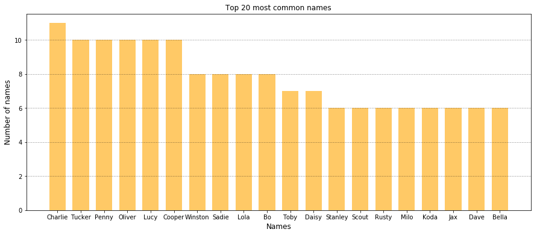

```python
plt.figure(figsize = (15,6))
plt.bar(the_most_common_names.name.sort_values(), the_most_common_names.num_of_names, width = 0.7, color = 'orange', alpha = 0.6)
plt.xticks(index, the_most_common_names.name)
plt.xlabel('Names', fontsize = 12)
plt.ylabel('Number of names', fontsize = 12)
plt.title('Top 20 most common names')
plt.grid(axis = 'y', linestyle=':', linewidth=0.5, color='black');
```

### Which breed gets the highest rating on average??

```
SELECT sum(rating) / count(prediction) as avg_rating, prediction, count(prediction) / 4 as number_of_appearances
FROM twitter_archive_master
GROUP BY prediction
HAVING avg_rating NOT LIKE 1.58699690402476 AND number_of_appearances > 1
ORDER BY avg_rating DESC
LIMIT 15
```

I have pulled data in which breeds are found and evaluated more than once.

```python
avg_rating = pd.read_csv('avg_rating_prediction.csv')
```

```python
avg_rating
```

|  | avg_rating | prediction | number_of_appearances |
| --- | --- | --- | --- |
| 0 | 1.250000 | Saluki | 4 |
| 1 | 1.247619 | Pomeranian | 42 |
| 2 | 1.240000 | Tibetan mastiff | 5 |
| 3 | 1.233333 | Briard | 3 |
| 4 | 1.214286 | Border terrier | 7 |
| 5 | 1.183333 | Irish setter | 6 |
| 6 | 1.175000 | Gordon setter | 4 |
| 7 | 1.171739 | Samoyed | 46 |
| 8 | 1.168478 | Golden retriever | 173 |
| 9 | 1.163158 | Kuvasz | 19 |
| 10 | 1.150000 | Giant schnauzer | 4 |
| 11 | 1.150000 | Wire-haired fox terrier | 2 |
| 12 | 1.150000 | Australian terrier | 2 |
| 13 | 1.147059 | Cocker spaniel | 34 |
| 14 | 1.146667 | Great pyrenees | 15 |

```python
index2 = range(len(avg_rating.prediction))
index2
```

```
range(0, 15)
```

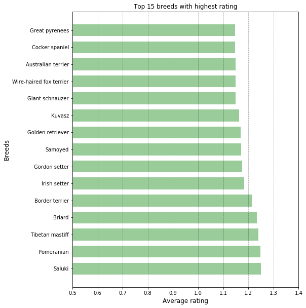

```python
plt.figure(figsize = (8, 10))
plt.barh(avg_rating.prediction.sort_values(), avg_rating.avg_rating, height = 0.7, color = 'green', alpha = 0.4)
plt.yticks(index2, avg_rating.prediction)
plt.xlabel('Average rating', fontsize = 12)
plt.ylabel('Breeds', fontsize = 12)
plt.title('Top 15 breeds with highest rating')
plt.xlim(0.5, 1.4)
plt.grid(axis = 'x', linestyle=':', linewidth=0.5, color='black');
```

### What is the most common stage of the dog in a DataFrame?

```
SELECT count(value) as num_of_appearances, value as stage_of_dogs
FROM twitter_archive_master
GROUP BY stage_of_dogs
HAVING stage_of_dogs NOT LIKE "NaN"
```

```python
num_app_dog_stages = pd.read_csv('share_of_stages_of_dogs.csv')
```

```python
num_app_dog_stages
```

|  | num_of_appearances | stage_of_dogs |
| --- | --- | --- |
| 0 | 80 | doggo |
| 1 | 8 | floofer |
| 2 | 221 | pupper |
| 3 | 24 | puppo |

```python
prop_of_dog_stages = num_app_dog_stages.copy()
```

```python
prop_of_dog_stages.num_of_appearances = prop_of_dog_stages.num_of_appearances / 333
```

```python
prop_of_dog_stages.rename(columns = {'num_of_appearances': 'propotion'}, inplace = True)
```

```python
prop_of_dog_stages
```

|  | propotion | stage_of_dogs |
| --- | --- | --- |
| 0 | 0.240240 | doggo |
| 1 | 0.024024 | floofer |
| 2 | 0.663664 | pupper |
| 3 | 0.072072 | puppo |

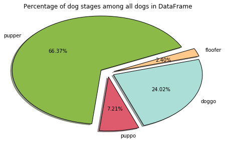

```python
propotions = prop_of_dog_stages.propotion
labels=prop_of_dog_stages.stage_of_dogs
explode = [0.08, 0.08, 0.1, 0.08]
radius = 1.1
colors = ['#ABDED7', '#FFC98B', '#8BBA48', '#DE5B6D']

plt.pie(propotions, labels = labels, explode = explode,
        startangle = 290, autopct = '%1.2f%%', radius = radius,
        colors = colors, shadow = True,
        wedgeprops = {'edgecolor' : 'black'});


plt.title('Percentage of dog stages among all dogs in DataFrame');
plt.tight_layout();
```